# Rdionica: priprema datoteke `podaci_upitnik.csv` za obradu

```r
install.packages(c('tidyverse', 'here',
                   'wrapr', 'conflicted',
                   # ovi paketi nisu učitani tijekom ovog
                   # dijela radionice:
                   'DataExplorer', 'naniar', 'visdat',
                   'skimr', 'janitor', 'psych'))
```

U ovom dijelu radionice proći ćemo put od sirovih podataka do podataka na kojima možemo provesti analizu. Prije nego što se bacimo na učitavanje i proučavanje sirovih podataka, učitat ćemo pakete koje ćemo koristiti.

Pakete učitavamo pozivanjem funkcije `library`, koja kao argument prima ime **jednog** paketa.

```r
# skupina paketa koja sadrži većinu paketa koje
# ćemo koristiti za baratanje podacima
library(tidyverse)
## Registered S3 methods overwritten by 'ggplot2':
##   method         from
##   [.quosures     rlang
##   c.quosures     rlang
##   print.quosures rlang
## Registered S3 method overwritten by 'rvest':
##   method            from
##   read_xml.response xml2
## ── Attaching packages ────────────────────────────────── tidyverse 1.2.1 ──
## ✔ ggplot2 3.1.1       ✔ purrr   0.3.2
## ✔ tibble  2.1.1       ✔ dplyr   0.8.0.1
## ✔ tidyr   0.8.3       ✔ stringr 1.4.0
## ✔ readr   1.3.1       ✔ forcats 0.4.0
## ── Conflicts ───────────────────────────────────── tidyverse_conflicts() ──
## ✖ dplyr::filter() masks stats::filter()
## ✖ dplyr::lag()    masks stats::lag()

# paket koji sadrži 'pipe' operatore
library(magrittr)
##
## Attaching package: 'magrittr'
## The following object is masked from 'package:purrr':
##
##     set_names
## The following object is masked from 'package:tidyr':
##
##     extract

# upozorava na konflikte u imenima funkcija
# koji se javljaju kad više paketa koristi isto
# ime
library(conflicted)

# omogućava učitavanje .SAV fielova
library(haven)

# omogućava učitavanje .xlsx fielova
library(readxl)

# paket koji sadrži neke zgodne olakšice
library(wrapr)

# olakšava korištenje relativnih file pathova
library(here)
## here() starts at /home/denis/Documents/rdionica
```

## Učitavanje podatka

Za početak, pogledat ćemo kako izgledaju naši sirovi podaci.

A da bismo to učinili, prvo ih moramo učitati u R.

Vidjet ćemo kako učitati tri vrste datoteka: SPSS-ov `.sav`, Excelov `.xls/xlsx` te generički *comma separated values* file - `.csv`.

### SPSS - .sav

`.sav` datoteke možemo učitati koristeći funkciju `read_sav` iz paketa `haven` (dio `tidyversea`). Funkcija kao argument prima samo put do datoteke koju želimo učitati.

```r
podaci_spss <- read_sav(here('podaci', 'podaci_upitnik.sav'))
```

Koristeći funkciju `head` (`tail`) možemo pogledati, po defaultu, prvih (posljednjih) 6 redova tablice. Ove funkcije pomažu nam pri pregledavanju strukture podataka i njihovih sirovih vrijednosti.

```r
head(podaci_spss)
## # A tibble: 6 x 65
##   attitudesAndNor… attitudesAndNor… attitudesAndNor… attitudesAndNor…
##              <dbl>            <dbl>            <dbl>            <dbl>
## 1                5                5                5                5
## 2                5                4                2                1
## 3                4                6                5                5
## 4                6                2                3                2
## 5                4                1                2                3
## 6                4                4                4                3
## # … with 61 more variables: attitudesAndNorms05 <dbl>,
## #   attitudesAndNorms06 <dbl>, attitudesAndNorms07 <dbl>,
## #   attitudesAndNorms08 <dbl>, callToAction <dbl>,
## #   charitableBehavior01 <dbl>, charitableBehavior02 <dbl>,
## #   descriptiveSocialNorms01 <dbl>, descriptiveSocialNorms02 <dbl>,
## #   descriptiveSocialNorms03 <dbl>, descriptiveSocialNorms04 <dbl>,
## #   mf_AuthoritySubversion <dbl>, mf_CareHarm <dbl>,
## #   mf_FairnessCheating <dbl>, mf_LoyaltyBetrayal <dbl>,
## #   mf_SanctityDegradation <dbl>, moralFoundations01 <dbl>,
## #   moralFoundations02 <dbl>, moralFoundations03 <dbl>,
## #   moralFoundations04 <dbl>, moralFoundations05 <dbl>,
## #   moralFoundations06 <dbl>, moralFoundations07 <dbl>,
## #   moralFoundations08 <dbl>, moralFoundations09 <dbl>,
## #   moralFoundations10 <dbl>, moralFoundations11 <dbl>,
## #   moralFoundations12 <dbl>, moralFoundations13 <dbl>,
## #   moralFoundations14 <dbl>, moralFoundations15 <dbl>,
## #   moralFoundations16 <dbl>, moralFoundations17 <dbl>,
## #   moralFoundations18 <dbl>, moralFoundations19 <dbl>,
## #   moralFoundations20 <dbl>, moralFoundations21 <dbl>,
## #   moralFoundations22 <dbl>, moralFoundations23 <dbl>,
## #   moralFoundations24 <dbl>, moralFoundations25 <dbl>,
## #   moralFoundations26 <dbl>, moralFoundations27 <dbl>,
## #   moralFoundations28 <dbl>, moralFoundations29 <dbl>,
## #   moralFoundations30 <dbl>, moralFoundations31 <dbl>,
## #   moralFoundations32 <dbl>, moralIdentityInternalization01 <dbl>,
## #   moralIdentityInternalization02 <dbl>,
## #   moralIdentityInternalization03 <dbl>,
## #   moralIdentityInternalization04 <dbl>,
## #   moralIdentityInternalization05 <dbl>, pi_age <dbl>,
## #   pi_education <chr>, pi_gender <chr>, pi_ideology <chr>,
## #   pi_income <chr>, pi_nationality <chr>, pi_previousDonations <chr>,
## #   V65 <chr>

tail(podaci_spss, 3)
## # A tibble: 3 x 65
##   attitudesAndNor… attitudesAndNor… attitudesAndNor… attitudesAndNor…
##              <dbl>            <dbl>            <dbl>            <dbl>
## 1                5                5                2                3
## 2                4                5                3                2
## 3                7                2                1               -1
## # … with 61 more variables: attitudesAndNorms05 <dbl>,
## #   attitudesAndNorms06 <dbl>, attitudesAndNorms07 <dbl>,
## #   attitudesAndNorms08 <dbl>, callToAction <dbl>,
## #   charitableBehavior01 <dbl>, charitableBehavior02 <dbl>,
## #   descriptiveSocialNorms01 <dbl>, descriptiveSocialNorms02 <dbl>,
## #   descriptiveSocialNorms03 <dbl>, descriptiveSocialNorms04 <dbl>,
## #   mf_AuthoritySubversion <dbl>, mf_CareHarm <dbl>,
## #   mf_FairnessCheating <dbl>, mf_LoyaltyBetrayal <dbl>,
## #   mf_SanctityDegradation <dbl>, moralFoundations01 <dbl>,
## #   moralFoundations02 <dbl>, moralFoundations03 <dbl>,
## #   moralFoundations04 <dbl>, moralFoundations05 <dbl>,
## #   moralFoundations06 <dbl>, moralFoundations07 <dbl>,
## #   moralFoundations08 <dbl>, moralFoundations09 <dbl>,
## #   moralFoundations10 <dbl>, moralFoundations11 <dbl>,
## #   moralFoundations12 <dbl>, moralFoundations13 <dbl>,
## #   moralFoundations14 <dbl>, moralFoundations15 <dbl>,
## #   moralFoundations16 <dbl>, moralFoundations17 <dbl>,
## #   moralFoundations18 <dbl>, moralFoundations19 <dbl>,
## #   moralFoundations20 <dbl>, moralFoundations21 <dbl>,
## #   moralFoundations22 <dbl>, moralFoundations23 <dbl>,
## #   moralFoundations24 <dbl>, moralFoundations25 <dbl>,
## #   moralFoundations26 <dbl>, moralFoundations27 <dbl>,
## #   moralFoundations28 <dbl>, moralFoundations29 <dbl>,
## #   moralFoundations30 <dbl>, moralFoundations31 <dbl>,
## #   moralFoundations32 <dbl>, moralIdentityInternalization01 <dbl>,
## #   moralIdentityInternalization02 <dbl>,
## #   moralIdentityInternalization03 <dbl>,
## #   moralIdentityInternalization04 <dbl>,
## #   moralIdentityInternalization05 <dbl>, pi_age <dbl>,
## #   pi_education <chr>, pi_gender <chr>, pi_ideology <chr>,
## #   pi_income <chr>, pi_nationality <chr>, pi_previousDonations <chr>,
## #   V65 <chr>
```

Kod nekih sudionika, unos pod `pi_education` je razdvojen u dva stupca, pri čemu je jedna vrijednost nasilno gurnuta u `pi_gender`. To je dovelo i do stvaranja nove varijable `V65`, koja sadrži vrijednosti koje bi se trebale javljati pod `pi_previous donations`. Dakle, kod nekih sudionika su vrijednosti iza `pi_education` pomaknute za jedno mjesto udesno.

Do toga je došlo jer je puni naziv jedne razine varijable `pi_education`: “Some professional diploma, no degree”. Zbog zareza u nazivu razine dolazi do pogreške u parsanju varijabli, pa dolazi do pomaka udesno i stvaranja varijable viška.

Ovaj problem lako možemo riješiti tako da otvorimo izvornu bazu podataka i samo napravimo find and replace kako bismo uklonili zarez smutnje. Lako ga je riješiti ako imamo SPSS. Druga opcija je korištenje besplatnog online `.sav` -> `.csv` konvertera (link se nalazi u referencama). Time ćemo dobiti datoteku koju možemo otvoriti u nekom text editoru (recimo, Notepadu), te učiniti potrebne promjene (opet find and replace). Treći način je, naravno, prtljanje po podacima u R-u, što ćemo ostaviti za kraj radionice.

### Excel - .xls(x)

Podatke u `.xlsx` (`.xls`) formatu možemo lako učitati pomoću funkcije `read_xlsx` (`read_xls`) iz paketa `readxl`. `readxl` je dio `tidyversea`, ali se ne učitava zajedno s njim, tako da ga moramo posebno učitavati.

```r
podaci_eksl <- read_xlsx(path = here('podaci', 'podaci_upitnik.xlsx'))

head(podaci_eksl)
## # A tibble: 6 x 64
##   attitudesAndNor… attitudesAndNor… attitudesAndNor… attitudesAndNor…
##              <dbl>            <dbl>            <dbl>            <dbl>
## 1                5                5                5                5
## 2                5                4                2                1
## 3                4                6                5                5
## 4                6                2                3                2
## 5                4                1                2                3
## 6                4                4                4                3
## # … with 60 more variables: attitudesAndNorms05 <dbl>,
## #   attitudesAndNorms06 <dbl>, attitudesAndNorms07 <dbl>,
## #   attitudesAndNorms08 <dbl>, callToAction <dbl>,
## #   charitableBehavior01 <dbl>, charitableBehavior02 <dbl>,
## #   descriptiveSocialNorms01 <dbl>, descriptiveSocialNorms02 <dbl>,
## #   descriptiveSocialNorms03 <dbl>, descriptiveSocialNorms04 <dbl>,
## #   mf_AuthoritySubversion <dbl>, mf_CareHarm <dbl>,
## #   mf_FairnessCheating <dbl>, mf_LoyaltyBetrayal <dbl>,
## #   mf_SanctityDegradation <dbl>, moralFoundations01 <dbl>,
## #   moralFoundations02 <dbl>, moralFoundations03 <dbl>,
## #   moralFoundations04 <dbl>, moralFoundations05 <dbl>,
## #   moralFoundations06 <dbl>, moralFoundations07 <dbl>,
## #   moralFoundations08 <dbl>, moralFoundations09 <dbl>,
## #   moralFoundations10 <dbl>, moralFoundations11 <dbl>,
## #   moralFoundations12 <dbl>, moralFoundations13 <dbl>,
## #   moralFoundations14 <dbl>, moralFoundations15 <dbl>,
## #   moralFoundations16 <dbl>, moralFoundations17 <dbl>,
## #   moralFoundations18 <dbl>, moralFoundations19 <dbl>,
## #   moralFoundations20 <dbl>, moralFoundations21 <dbl>,
## #   moralFoundations22 <dbl>, moralFoundations23 <dbl>,
## #   moralFoundations24 <dbl>, moralFoundations25 <dbl>,
## #   moralFoundations26 <dbl>, moralFoundations27 <dbl>,
## #   moralFoundations28 <dbl>, moralFoundations29 <dbl>,
## #   moralFoundations30 <dbl>, moralFoundations31 <dbl>,
## #   moralFoundations32 <dbl>, moralIdentityInternalization01 <dbl>,
## #   moralIdentityInternalization02 <dbl>,
## #   moralIdentityInternalization03 <dbl>,
## #   moralIdentityInternalization04 <dbl>,
## #   moralIdentityInternalization05 <dbl>, pi_age <dbl>,
## #   pi_education <chr>, pi_gender <chr>, pi_ideology <chr>,
## #   pi_income <chr>, pi_nationality <chr>, pi_previousDonations <chr>

str(podaci_eksl)
## Classes 'tbl_df', 'tbl' and 'data.frame':    100 obs. of  64 variables:
##  $ attitudesAndNorms01           : num  5 5 4 6 4 4 6 4 3 5 ...
##  $ attitudesAndNorms02           : num  5 4 6 2 1 4 0 4 7 7 ...
##  $ attitudesAndNorms03           : num  5 2 5 3 2 4 3 5 6 7 ...
##  $ attitudesAndNorms04           : num  5 1 5 2 3 3 3 7 5 6 ...
##  $ attitudesAndNorms05           : num  4 2 3 2 1 4 2 4 4 6 ...
##  $ attitudesAndNorms06           : num  3 2 2 3 2 3 3 3 3 4 ...
##  $ attitudesAndNorms07           : num  4 3 4 5 4 5 6 4 4 5 ...
##  $ attitudesAndNorms08           : num  6 7 5 6 5 5 7 5 3 5 ...
##  $ callToAction                  : num  7 6 7 1 8 7 11 8 3 7 ...
##  $ charitableBehavior01          : num  37 18 7 14 0 37 33 29 16 6 ...
##  $ charitableBehavior02          : num  4 3 3 5 0 2 4 3 2 3 ...
##  $ descriptiveSocialNorms01      : num  4 3 3 1 3 1 2 4 3 4 ...
##  $ descriptiveSocialNorms02      : num  3 1 3 1 1 1 2 3 3 5 ...
##  $ descriptiveSocialNorms03      : num  2 3 2 2 2 3 3 4 4 5 ...
##  $ descriptiveSocialNorms04      : num  2 1 5 3 4 2 2 2 2 4 ...
##  $ mf_AuthoritySubversion        : num  1 1 2 2 2 0 2 1 1 2 ...
##  $ mf_CareHarm                   : num  3 3 3 3 4 3 4 3 3 4 ...
##  $ mf_FairnessCheating           : num  3 3 4 3 2 4 4 5 3 4 ...
##  $ mf_LoyaltyBetrayal            : num  2 2 2 3 2 1 2 0 0 1 ...
##  $ mf_SanctityDegradation        : num  1 1 1 1 1 -1 1 -1 1 1 ...
##  $ moralFoundations01            : num  4 3 4 3 3 4 5 3 4 4 ...
##  $ moralFoundations02            : num  4 3 4 3 1 4 4 4 2 5 ...
##  $ moralFoundations03            : num  3 0 2 1 1 0 2 0 -1 0 ...
##  $ moralFoundations04            : num  1 0 2 2 2 0 2 0 1 2 ...
##  $ moralFoundations05            : num  2 2 1 3 3 -1 3 1 1 2 ...
##  $ moralFoundations06            : num  0 0 0 2 -1 1 0 0 -1 1 ...
##  $ moralFoundations07            : num  4 3 4 4 5 2 4 4 3 4 ...
##  $ moralFoundations08            : num  4 3 4 3 3 4 5 4 3 5 ...
##  $ moralFoundations09            : num  3 3 2 4 3 3 3 1 -1 1 ...
##  $ moralFoundations10            : num  0 -1 1 3 2 0 2 1 1 1 ...
##  $ moralFoundations11            : num  1 3 1 0 1 -1 2 0 3 3 ...
##  $ moralFoundations12            : num  6 5 4 5 4 4 5 4 3 5 ...
##  $ moralFoundations13            : num  3 5 4 5 5 3 4 5 4 5 ...
##  $ moralFoundations14            : num  4 2 1 1 3 3 3 1 3 2 ...
##  $ moralFoundations15            : num  3 2 2 1 2 3 3 2 5 3 ...
##  $ moralFoundations16            : num  3 1 1 2 -1 1 -2 2 0 1 ...
##  $ moralFoundations17            : num  2 5 3 4 4 4 3 4 3 3 ...
##  $ moralFoundations18            : num  2 3 3 4 5 2 4 5 4 4 ...
##  $ moralFoundations19            : num  0 2 4 2 2 2 4 4 4 2 ...
##  $ moralFoundations20            : num  0 1 0 4 1 3 3 3 2 2 ...
##  $ moralFoundations21            : num  0 1 1 1 3 3 1 2 1 -1 ...
##  $ moralFoundations22            : num  4 4 6 4 4 3 5 3 5 5 ...
##  $ moralFoundations23            : num  3 3 4 2 4 0 3 4 3 3 ...
##  $ moralFoundations24            : num  4 3 1 5 2 3 2 6 2 3 ...
##  $ moralFoundations25            : num  0 0 1 2 0 3 1 2 2 1 ...
##  $ moralFoundations26            : num  1 1 1 5 0 2 2 3 1 1 ...
##  $ moralFoundations27            : num  1 1 0 1 1 1 -1 2 0 1 ...
##  $ moralFoundations28            : num  0 -1 2 -1 -1 1 3 1 4 1 ...
##  $ moralFoundations29            : num  1 1 3 2 4 1 4 2 2 0 ...
##  $ moralFoundations30            : num  1 1 1 1 2 1 1 0 2 2 ...
##  $ moralFoundations31            : num  3 2 1 5 2 2 4 3 3 2 ...
##  $ moralFoundations32            : num  1 0 0 4 2 1 0 1 2 1 ...
##  $ moralIdentityInternalization01: num  5 4 6 6 4 4 5 3 6 5 ...
##  $ moralIdentityInternalization02: num  2 3 5 4 3 6 5 2 4 5 ...
##  $ moralIdentityInternalization03: num  1 1 1 1 1 1 1 1 1 1 ...
##  $ moralIdentityInternalization04: num  2 3 1 3 2 1 3 3 3 1 ...
##  $ moralIdentityInternalization05: num  3 4 5 4 4 4 5 3 4 5 ...
##  $ pi_age                        : num  3 20 20 19 22 25 23 41 16 17 ...
##  $ pi_education                  : chr  "Some professional diploma, no degree" "Master's degree" "High school" "Master's degree" ...
##  $ pi_gender                     : chr  "Male" "Male" "Male" "Male" ...
##  $ pi_ideology                   : chr  "Neither liberal or conservative" "Very liberal (left)" "Neither liberal or conservative" "Very liberal (left)" ...
##  $ pi_income                     : chr  "Somewhat below the average" "Somewhat above the average" "Somewhat above the average" "Somewhat above the average" ...
##  $ pi_nationality                : chr  "American" "USA" "Turkish" "United States of America" ...
##  $ pi_previousDonations          : chr  "Rarely" "Regularly" "Rarely" "Rarely" ...
```

### Comma separated values - .csv

*Comma separeted value* datoteke su točno to što ime kaže - podaci koji su strukturirani kao vrijednosti odvojene zarezima, gdje se svaki unos (na primjer sudionik) nalazi u zasebnom redu, a vrijednosti varijabli koje su uz njega povezane ispisane su redom i odvojene su zarezima. U prvom redu (koji funkcije u R-u često nazivaju **header**) obično se nalaze imena varijabli, a u ostalim redovima su njihove vrijednosti.

Ovako izgledaju prva dva reda i prvih nekoliko stupaca datoteke `podaci_upitnik.csv`:

```
attitudesAndNorms01,attitudesAndNorms02,attitudesAndNorms03, ...
5,5,5,5,4, ...
```

Podatke u `.csv` formatu možemo učitati pomoću funkcije `read_csv` iz `readr` paketa (koji je automatski učitan kad smo učitali `tidyverse`). Osnovni (base) R ima funkciju `read.csv` koja obavlja isti zadatak, ali neki R developeri preporučuju korištenje `read_csv` funkcije (na primjer, Hadley Wickham i Garret Grolemund: http://r4ds.had.co.nz/import.html). U skladu s tom preporukom, koristit ćemo `read_csv`. Podatke iz datoteke `podaci_upitnik.csv` možemo učitati ovako:

```r
podaci <- read_csv(here('podaci', 'podaci_upitnik.csv'))
## Parsed with column specification:
## cols(
##   .default = col_double(),
##   pi_education = col_character(),
##   pi_gender = col_character(),
##   pi_ideology = col_character(),
##   pi_income = col_character(),
##   pi_nationality = col_character(),
##   pi_previousDonations = col_character()
## )
## See spec(...) for full column specifications.
```

Poruka koju dobivamo obavještava nas o tome kako su određene varijable reprezentirane. Vidimo da su varijable koje počinju s `pi` reprezentirane kao `character`. Ako pozovemo funkciju `spec`, vidjet ćemo specifikacije svih varijabli. Budući da pozivanjem funkcije `str` zapravo dobivamo manje-više iste podatke, pozvat ćemo samo nju. Njen output pomoći će nam da vidimo jesu li podaci reprezentirani onako kako bismo očekivali.

```r
str(podaci)
## Classes 'spec_tbl_df', 'tbl_df', 'tbl' and 'data.frame': 100 obs. of  64 variables:
##  $ attitudesAndNorms01           : num  5 5 4 6 4 4 6 4 3 5 ...
##  $ attitudesAndNorms02           : num  5 4 6 2 1 4 0 4 7 7 ...
##  $ attitudesAndNorms03           : num  5 2 5 3 2 4 3 5 6 7 ...
##  $ attitudesAndNorms04           : num  5 1 5 2 3 3 3 7 5 6 ...
##  $ attitudesAndNorms05           : num  4 2 3 2 1 4 2 4 4 6 ...
##  $ attitudesAndNorms06           : num  3 2 2 3 2 3 3 3 3 4 ...
##  $ attitudesAndNorms07           : num  4 3 4 5 4 5 6 4 4 5 ...
##  $ attitudesAndNorms08           : num  6 7 5 6 5 5 7 5 3 5 ...
##  $ callToAction                  : num  7 6 7 1 8 7 11 8 3 7 ...
##  $ charitableBehavior01          : num  37 18 7 14 0 37 33 29 16 6 ...
##  $ charitableBehavior02          : num  4 3 3 5 0 2 4 3 2 3 ...
##  $ descriptiveSocialNorms01      : num  4 3 3 1 3 1 2 4 3 4 ...
##  $ descriptiveSocialNorms02      : num  3 1 3 1 1 1 2 3 3 5 ...
##  $ descriptiveSocialNorms03      : num  2 3 2 2 2 3 3 4 4 5 ...
##  $ descriptiveSocialNorms04      : num  2 1 5 3 4 2 2 2 2 4 ...
##  $ mf_AuthoritySubversion        : num  1 1 2 2 2 0 2 1 1 2 ...
##  $ mf_CareHarm                   : num  3 3 3 3 4 3 4 3 3 4 ...
##  $ mf_FairnessCheating           : num  3 3 4 3 2 4 4 5 3 4 ...
##  $ mf_LoyaltyBetrayal            : num  2 2 2 3 2 1 2 0 0 1 ...
##  $ mf_SanctityDegradation        : num  1 1 1 1 1 -1 1 -1 1 1 ...
##  $ moralFoundations01            : num  4 3 4 3 3 4 5 3 4 4 ...
##  $ moralFoundations02            : num  4 3 4 3 1 4 4 4 2 5 ...
##  $ moralFoundations03            : num  3 0 2 1 1 0 2 0 -1 0 ...
##  $ moralFoundations04            : num  1 0 2 2 2 0 2 0 1 2 ...
##  $ moralFoundations05            : num  2 2 1 3 3 -1 3 1 1 2 ...
##  $ moralFoundations06            : num  0 0 0 2 -1 1 0 0 -1 1 ...
##  $ moralFoundations07            : num  4 3 4 4 5 2 4 4 3 4 ...
##  $ moralFoundations08            : num  4 3 4 3 3 4 5 4 3 5 ...
##  $ moralFoundations09            : num  3 3 2 4 3 3 3 1 -1 1 ...
##  $ moralFoundations10            : num  0 -1 1 3 2 0 2 1 1 1 ...
##  $ moralFoundations11            : num  1 3 1 0 1 -1 2 0 3 3 ...
##  $ moralFoundations12            : num  6 5 4 5 4 4 5 4 3 5 ...
##  $ moralFoundations13            : num  3 5 4 5 5 3 4 5 4 5 ...
##  $ moralFoundations14            : num  4 2 1 1 3 3 3 1 3 2 ...
##  $ moralFoundations15            : num  3 2 2 1 2 3 3 2 5 3 ...
##  $ moralFoundations16            : num  3 1 1 2 -1 1 -2 2 0 1 ...
##  $ moralFoundations17            : num  2 5 3 4 4 4 3 4 3 3 ...
##  $ moralFoundations18            : num  2 3 3 4 5 2 4 5 4 4 ...
##  $ moralFoundations19            : num  0 2 4 2 2 2 4 4 4 2 ...
##  $ moralFoundations20            : num  0 1 0 4 1 3 3 3 2 2 ...
##  $ moralFoundations21            : num  0 1 1 1 3 3 1 2 1 -1 ...
##  $ moralFoundations22            : num  4 4 6 4 4 3 5 3 5 5 ...
##  $ moralFoundations23            : num  3 3 4 2 4 0 3 4 3 3 ...
##  $ moralFoundations24            : num  4 3 1 5 2 3 2 6 2 3 ...
##  $ moralFoundations25            : num  0 0 1 2 0 3 1 2 2 1 ...
##  $ moralFoundations26            : num  1 1 1 5 0 2 2 3 1 1 ...
##  $ moralFoundations27            : num  1 1 0 1 1 1 -1 2 0 1 ...
##  $ moralFoundations28            : num  0 -1 2 -1 -1 1 3 1 4 1 ...
##  $ moralFoundations29            : num  1 1 3 2 4 1 4 2 2 0 ...
##  $ moralFoundations30            : num  1 1 1 1 2 1 1 0 2 2 ...
##  $ moralFoundations31            : num  3 2 1 5 2 2 4 3 3 2 ...
##  $ moralFoundations32            : num  1 0 0 4 2 1 0 1 2 1 ...
##  $ moralIdentityInternalization01: num  5 4 6 6 4 4 5 3 6 5 ...
##  $ moralIdentityInternalization02: num  2 3 5 4 3 6 5 2 4 5 ...
##  $ moralIdentityInternalization03: num  1 1 1 1 1 1 1 1 1 1 ...
##  $ moralIdentityInternalization04: num  2 3 1 3 2 1 3 3 3 1 ...
##  $ moralIdentityInternalization05: num  3 4 5 4 4 4 5 3 4 5 ...
##  $ pi_age                        : num  3 20 20 19 22 25 23 41 16 17 ...
##  $ pi_education                  : chr  "Some professional diploma, no degree" "Master's degree" "High school" "Master's degree" ...
##  $ pi_gender                     : chr  "Male" "Male" "Male" "Male" ...
##  $ pi_ideology                   : chr  "Neither liberal or conservative" "Very liberal (left)" "Neither liberal or conservative" "Very liberal (left)" ...
##  $ pi_income                     : chr  "Somewhat below the average" "Somewhat above the average" "Somewhat above the average" "Somewhat above the average" ...
##  $ pi_nationality                : chr  "American" "USA" "Turkish" "United States of America" ...
##  $ pi_previousDonations          : chr  "Rarely" "Regularly" "Rarely" "Rarely" ...
##  - attr(*, "spec")=
##   .. cols(
##   ..   attitudesAndNorms01 = col_double(),
##   ..   attitudesAndNorms02 = col_double(),
##   ..   attitudesAndNorms03 = col_double(),
##   ..   attitudesAndNorms04 = col_double(),
##   ..   attitudesAndNorms05 = col_double(),
##   ..   attitudesAndNorms06 = col_double(),
##   ..   attitudesAndNorms07 = col_double(),
##   ..   attitudesAndNorms08 = col_double(),
##   ..   callToAction = col_double(),
##   ..   charitableBehavior01 = col_double(),
##   ..   charitableBehavior02 = col_double(),
##   ..   descriptiveSocialNorms01 = col_double(),
##   ..   descriptiveSocialNorms02 = col_double(),
##   ..   descriptiveSocialNorms03 = col_double(),
##   ..   descriptiveSocialNorms04 = col_double(),
##   ..   mf_AuthoritySubversion = col_double(),
##   ..   mf_CareHarm = col_double(),
##   ..   mf_FairnessCheating = col_double(),
##   ..   mf_LoyaltyBetrayal = col_double(),
##   ..   mf_SanctityDegradation = col_double(),
##   ..   moralFoundations01 = col_double(),
##   ..   moralFoundations02 = col_double(),
##   ..   moralFoundations03 = col_double(),
##   ..   moralFoundations04 = col_double(),
##   ..   moralFoundations05 = col_double(),
##   ..   moralFoundations06 = col_double(),
##   ..   moralFoundations07 = col_double(),
##   ..   moralFoundations08 = col_double(),
##   ..   moralFoundations09 = col_double(),
##   ..   moralFoundations10 = col_double(),
##   ..   moralFoundations11 = col_double(),
##   ..   moralFoundations12 = col_double(),
##   ..   moralFoundations13 = col_double(),
##   ..   moralFoundations14 = col_double(),
##   ..   moralFoundations15 = col_double(),
##   ..   moralFoundations16 = col_double(),
##   ..   moralFoundations17 = col_double(),
##   ..   moralFoundations18 = col_double(),
##   ..   moralFoundations19 = col_double(),
##   ..   moralFoundations20 = col_double(),
##   ..   moralFoundations21 = col_double(),
##   ..   moralFoundations22 = col_double(),
##   ..   moralFoundations23 = col_double(),
##   ..   moralFoundations24 = col_double(),
##   ..   moralFoundations25 = col_double(),
##   ..   moralFoundations26 = col_double(),
##   ..   moralFoundations27 = col_double(),
##   ..   moralFoundations28 = col_double(),
##   ..   moralFoundations29 = col_double(),
##   ..   moralFoundations30 = col_double(),
##   ..   moralFoundations31 = col_double(),
##   ..   moralFoundations32 = col_double(),
##   ..   moralIdentityInternalization01 = col_double(),
##   ..   moralIdentityInternalization02 = col_double(),
##   ..   moralIdentityInternalization03 = col_double(),
##   ..   moralIdentityInternalization04 = col_double(),
##   ..   moralIdentityInternalization05 = col_double(),
##   ..   pi_age = col_double(),
##   ..   pi_education = col_character(),
##   ..   pi_gender = col_character(),
##   ..   pi_ideology = col_character(),
##   ..   pi_income = col_character(),
##   ..   pi_nationality = col_character(),
##   ..   pi_previousDonations = col_character()
##   .. )
```

Obrisat ćemo specifikacije varijabli da ne zakrčuju output. `attr` nam omogućuje da pristupimo raznim **atributima** objekata u R-u. Ovdje, dakle, pristupamo atributu `spec` objekta `podaci`, te ga brišemo upisujući vrijednost `NULL`.

```r
attr(podaci, 'spec') <- NULL

head(podaci)
## # A tibble: 6 x 64
##   attitudesAndNor… attitudesAndNor… attitudesAndNor… attitudesAndNor…
##              <dbl>            <dbl>            <dbl>            <dbl>
## 1                5                5                5                5
## 2                5                4                2                1
## 3                4                6                5                5
## 4                6                2                3                2
## 5                4                1                2                3
## 6                4                4                4                3
## # … with 60 more variables: attitudesAndNorms05 <dbl>,
## #   attitudesAndNorms06 <dbl>, attitudesAndNorms07 <dbl>,
## #   attitudesAndNorms08 <dbl>, callToAction <dbl>,
## #   charitableBehavior01 <dbl>, charitableBehavior02 <dbl>,
## #   descriptiveSocialNorms01 <dbl>, descriptiveSocialNorms02 <dbl>,
## #   descriptiveSocialNorms03 <dbl>, descriptiveSocialNorms04 <dbl>,
## #   mf_AuthoritySubversion <dbl>, mf_CareHarm <dbl>,
## #   mf_FairnessCheating <dbl>, mf_LoyaltyBetrayal <dbl>,
## #   mf_SanctityDegradation <dbl>, moralFoundations01 <dbl>,
## #   moralFoundations02 <dbl>, moralFoundations03 <dbl>,
## #   moralFoundations04 <dbl>, moralFoundations05 <dbl>,
## #   moralFoundations06 <dbl>, moralFoundations07 <dbl>,
## #   moralFoundations08 <dbl>, moralFoundations09 <dbl>,
## #   moralFoundations10 <dbl>, moralFoundations11 <dbl>,
## #   moralFoundations12 <dbl>, moralFoundations13 <dbl>,
## #   moralFoundations14 <dbl>, moralFoundations15 <dbl>,
## #   moralFoundations16 <dbl>, moralFoundations17 <dbl>,
## #   moralFoundations18 <dbl>, moralFoundations19 <dbl>,
## #   moralFoundations20 <dbl>, moralFoundations21 <dbl>,
## #   moralFoundations22 <dbl>, moralFoundations23 <dbl>,
## #   moralFoundations24 <dbl>, moralFoundations25 <dbl>,
## #   moralFoundations26 <dbl>, moralFoundations27 <dbl>,
## #   moralFoundations28 <dbl>, moralFoundations29 <dbl>,
## #   moralFoundations30 <dbl>, moralFoundations31 <dbl>,
## #   moralFoundations32 <dbl>, moralIdentityInternalization01 <dbl>,
## #   moralIdentityInternalization02 <dbl>,
## #   moralIdentityInternalization03 <dbl>,
## #   moralIdentityInternalization04 <dbl>,
## #   moralIdentityInternalization05 <dbl>, pi_age <dbl>,
## #   pi_education <chr>, pi_gender <chr>, pi_ideology <chr>,
## #   pi_income <chr>, pi_nationality <chr>, pi_previousDonations <chr>
```

Osnovnu deskriptivnu statistiku možemo dobiti pomoću generičke funkcije `summary`. Generičke funkcije primaju objekte različitih tipova, a njihov output ovisi o tipu objekta. Primjerice, ako u `summary` stavimo `data.frame`, dobit ćemo grubu deskriptivnu statistiku njegovih stupaca. Ako u funkciju stavimo regresijski model, dobit ćemo informacije o modelu. Idemo vidjeti output tih dviju funkcija kad u nju stavimo neke numeričke i neke kategorijalne stupce iz našeg `data.framea` `podaci`.

```r
summary(podaci[, wrapr::qc(attitudesAndNorms01, pi_education, pi_gender)])
##  attitudesAndNorms01 pi_education        pi_gender
##  Min.   :2.00        Length:100         Length:100
##  1st Qu.:4.00        Class :character   Class :character
##  Median :5.00        Mode  :character   Mode  :character
##  Mean   :5.04
##  3rd Qu.:6.00
##  Max.   :8.00
```

Vidimo tri stvari: (1) `summary` nije pretjerano koristan za varijable koje su tipa `character` i (2-3) pojavili su se nova sintaksa i nova funkcija.

`qc` je funkcija iz paketa `wrapr` koja nas oslobađa pisanja navodnika pri korištenju funkcije `c`. `qc` je, dakle, *quoted combine*.

Korištenjem `::` sintakse označili smo da je funkcija `qc` iz paketa `wrapr`. Pri pozivanju funkcija iz paketa **nije nužno** pisati `::`; to smo vidjeli kod pozivanja funkcije `read_csv` iz paketa `readr` (ili `read_xls` ili `read_spss`).

Ipak, važno je znati tu sintaksu iz dva razloga.

Prvo, korištenjem `::` možemo pozvati funkciju iz paketa koji prethodno nismo učitali.

Drugo, u slučaju da dva paketa imaju funkcije koje se jednako zovu, `::` nam omogućava da specificiramo koju funkciju želimo pozvati. Budući da smo učitali paket `conflicted`, R će nas upozoriti ako dođe do konflikta te nas tražiti da specificiramo koju funkciju hoćemo pozvati, koristeći `::`.

Iskoristit ćemo trenutak i upoznati se s još jednom zgodnom funkcijom za dobivanje deskriptivnih podataka: `skim`. Radi preglednosti, probrat ćemo par varijabli različitih tipova.

Nastavit ću koristiti `::` notaciju tako da bude jasno iz kojeg paketa dolazi koja funkcija (osim ako je spomenuto u tekstu ili ako je funkcija iz base R-a).

```r
print(skimr::skim(podaci[, qc(pi_education, attitudesAndNorms01,
                              attitudesAndNorms02, attitudesAndNorms03,
                              mf_CareHarm, pi_income)]))
```

[output not shown]

Ovdje smo iskoristili `::` notaciju da bismo pozvali funkciju iz paketa koji ranije nije učitan. Dobro je znati i za funkciju `describe` iz paketa `psych`, koja daje nešto detaljniju deskriptivnu statistiku numeričkih varijabli.

```r
podaci %>%
dplyr::select(., attitudesAndNorms01:attitudesAndNorms03,
              mf_CareHarm, pi_income, pi_education) %>%
psych::describe(.) %>% print(.)
## Warning in psych::describe(.): NAs introduced by coercion

## Warning in psych::describe(.): NAs introduced by coercion
## Warning in FUN(newX[, i], ...): no non-missing arguments to min; returning
## Inf

## Warning in FUN(newX[, i], ...): no non-missing arguments to min; returning
## Inf
## Warning in FUN(newX[, i], ...): no non-missing arguments to max; returning
## -Inf

## Warning in FUN(newX[, i], ...): no non-missing arguments to max; returning
## -Inf
##                     vars   n mean   sd median trimmed  mad min  max range
## attitudesAndNorms01    1 100 5.04 1.43      5    5.06 1.48   2    8     6
## attitudesAndNorms02    2 100 3.22 2.03      3    3.27 1.48  -2    7     9
## attitudesAndNorms03    3 100 3.06 1.88      3    3.05 1.48  -2    8    10
## mf_CareHarm            4 100 3.56 0.83      3    3.50 1.48   2    6     4
## pi_income*             5 100  NaN   NA     NA     NaN   NA Inf -Inf  -Inf
## pi_education*          6 100  NaN   NA     NA     NaN   NA Inf -Inf  -Inf
##                      skew kurtosis   se
## attitudesAndNorms01 -0.19    -0.59 0.14
## attitudesAndNorms02 -0.17    -0.47 0.20
## attitudesAndNorms03  0.02     0.12 0.19
## mf_CareHarm          0.54     0.23 0.08
## pi_income*             NA       NA   NA
## pi_education*          NA       NA   NA
```

I dalje nije korisno za `character` varijable, ali omogućava digresiju u svijet pipa.

## Pipe

Pipe su posebni operatori iz `magrittr` paketa. One omogućavaju kraće i, često, razumljivije pisanje koda. Pipa uzima output izraza sa svoje lijeve strane i daje ga kao argument funkciji na svojoj desnoj strani. Osnovna pipa je `%>%`. Ona se nalazi i u paketu `dplyr` (koji se učitava kad učitamo `tidyverse`) i u paketu `magrittr`. Posebno smo učitali `magrittr` jer s njim dolaze i neke pipe kojih nema u `dplyru`. Sad ćemo proći kroz pipe koje `magrittr` nudi.

### %>%

Kao što je rečeno, ovo je osnovna pipa. Ona uzima output izraza s lijeve strane i koristi ga kao input za izraz s desne strane.

Dakle:

```r
(2 + 2) %>% sqrt(.)
## [1] 2

(2 + 2) %>% sqrt()
## [1] 2

(2 + 2) %>% sqrt
## [1] 2

sqrt((2 + 2))
## [1] 2
```

Trenutačno ne izgleda kao neka ušteda, što je u redu. Kasnije ćemo vidjeti primjere u kojima su pipe dosta zgodnije. Kod korištenja pipa, `.` označava output iz funkcije s lijeve strane. Po defaultu, ako `.` nije eksplicitno navedena, pipa će točku staviti na mjesto prvog argumenta. Takav default uglavnom jako dobro funkcionira s funkcijama iz `tidyversea` jer one imaju dosta uniformnu sintaksu, koja je prilagođena za pipe. Ipak, nekad takvo ponašanje nije poželjno. Pokušajmo grafirati dva brojčana vektora - jedan od njih ćemo spremiti u varijablu, a drugi ćemo direktno dati pipi.

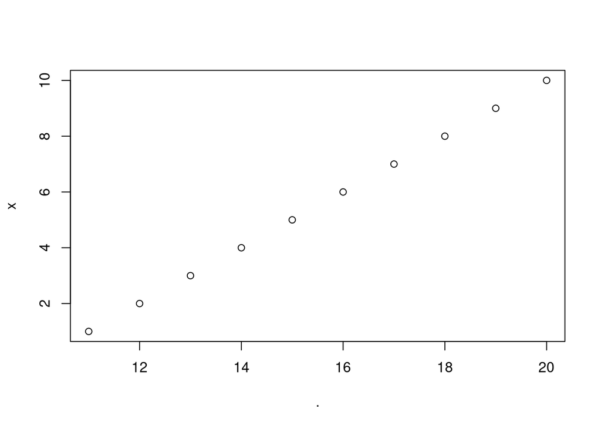

```r
# ova vrijednost treba ići na x os
x <- 1:10

# vektor koji ćemo sad stvoriti treba ići na y os
# ovaj kod jednak je ovom -> 11:20 %>% plot(., x)
# plot je također generička funkcija
11:20 %>% plot(x)
```

Da bismo izbjegli takvo ponašanje, možemo eksplicitno napisati točku, ili izraz opkoliti vitičastim zagradama.

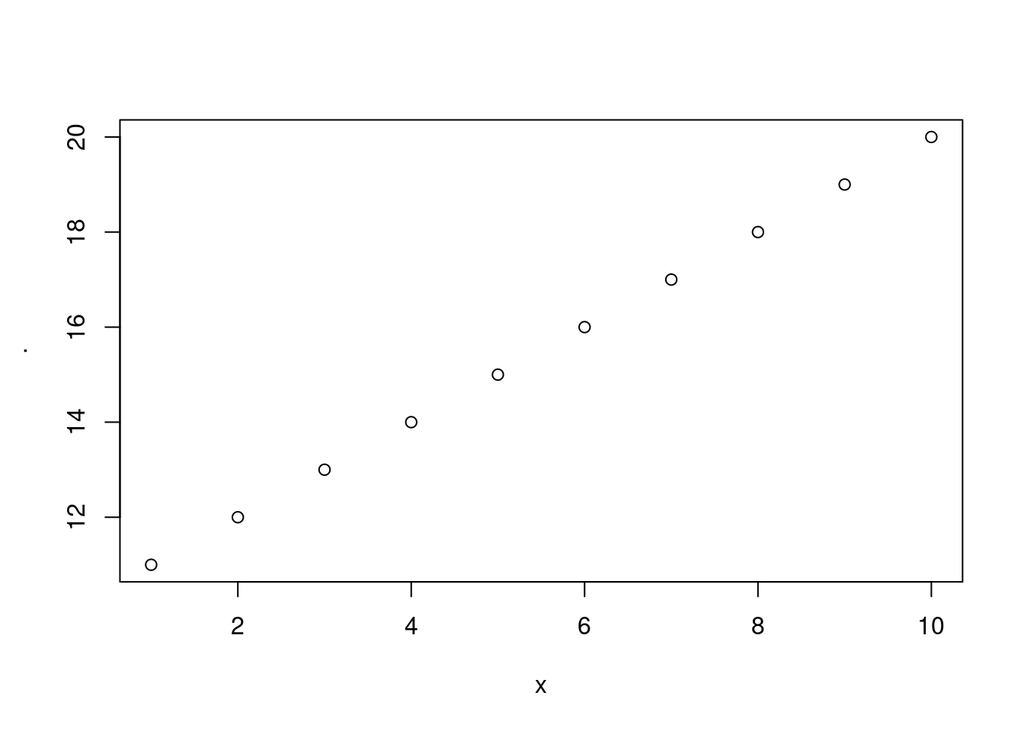

```r
11:20 %>% {plot(x, .)}
```

Sad ćemo `x` staviti u `data.frame` i pridružiti mu `y`.

```r
za_graf <- data.frame(x = 1:10, y = 11:20)

str(za_graf)
## 'data.frame':    10 obs. of  2 variables:
##  $ x: int  1 2 3 4 5 6 7 8 9 10
##  $ y: int  11 12 13 14 15 16 17 18 19 20
```

Ponovno ćemo pokušati plotati vrijednosti tako što `za_graf` stavimo u pipu.

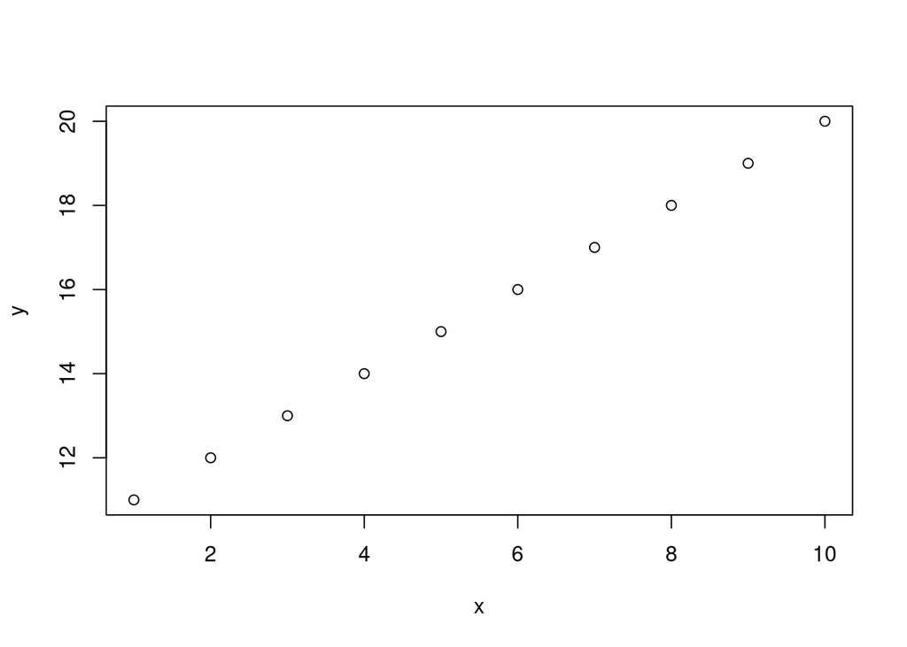

```r
za_graf %>% plot(.)
```

Da bismo zamijenili osi, možemo učiniti sljedeće:

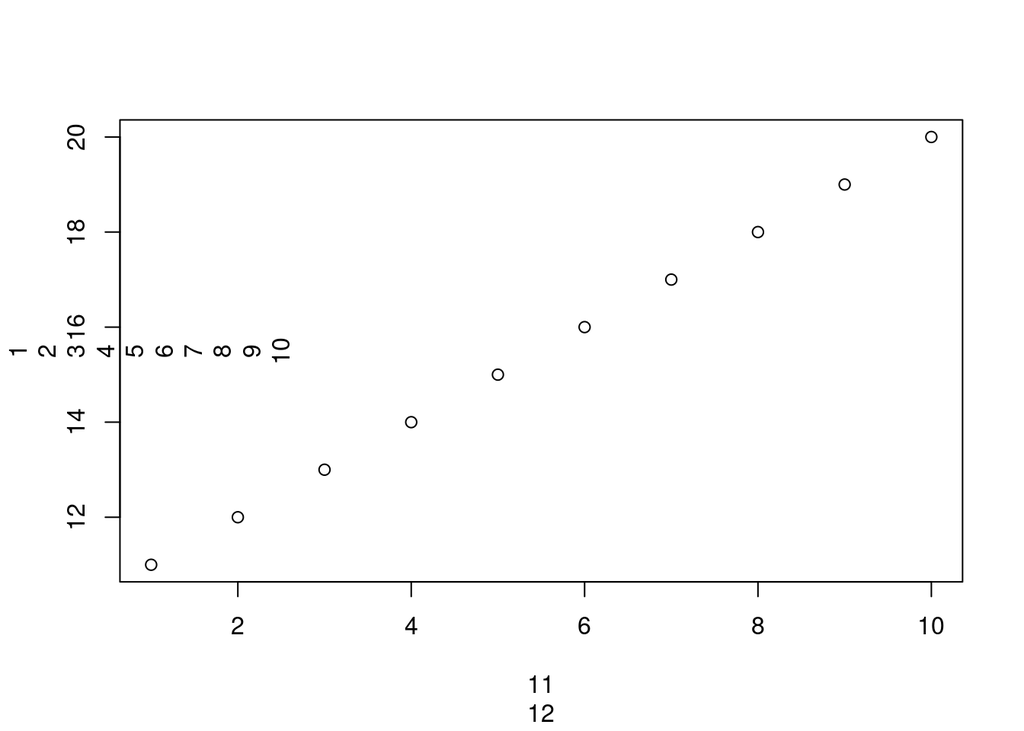

```r
za_graf %>% plot(.$y, .$x)
```

To jest, ne možemo jer se gornji kod interpretira kao

[output not shown]

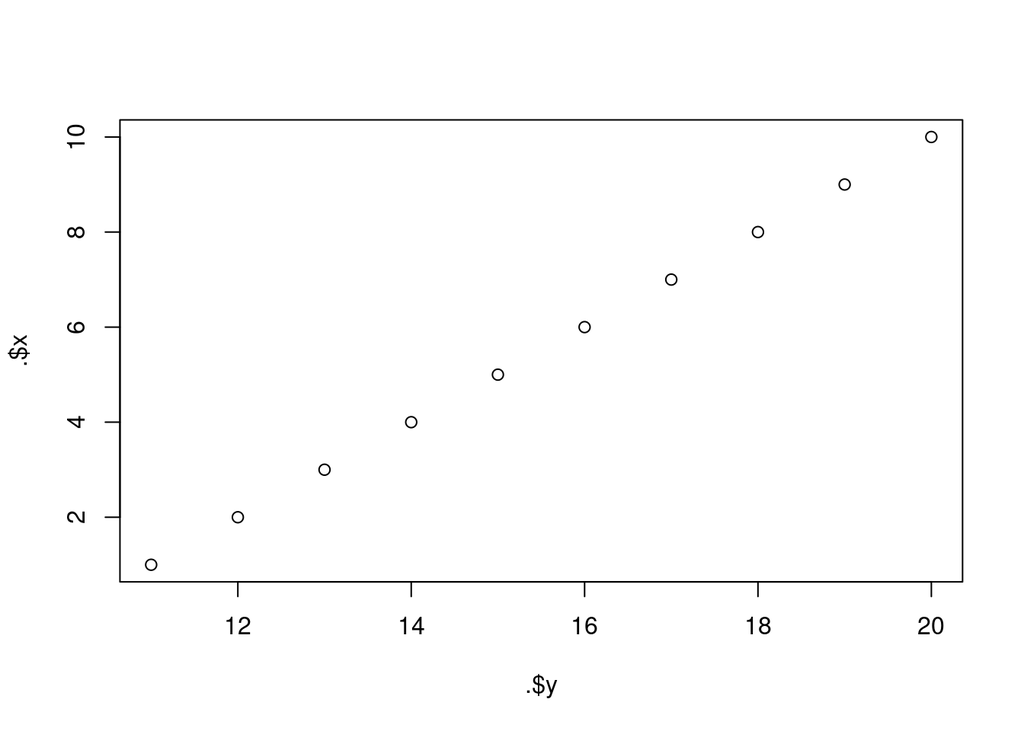

Da se smanje takve konfuzije, neki preporučuju da se `.` uvijek piše, tako da je to praksa koju ćemo ovdje usvojiti. No, osim zatvaranja izraza s desne strane u zagrade, možemo iskoristiti jednu drugu pipu.

### %$%

`%$%` je *variable exposition* pipa. Ona nam daje direktan pristup varijablama koje se nalaze u objektu kojim baratamo. Gornji problem mogli bismo riješiti i ovako:

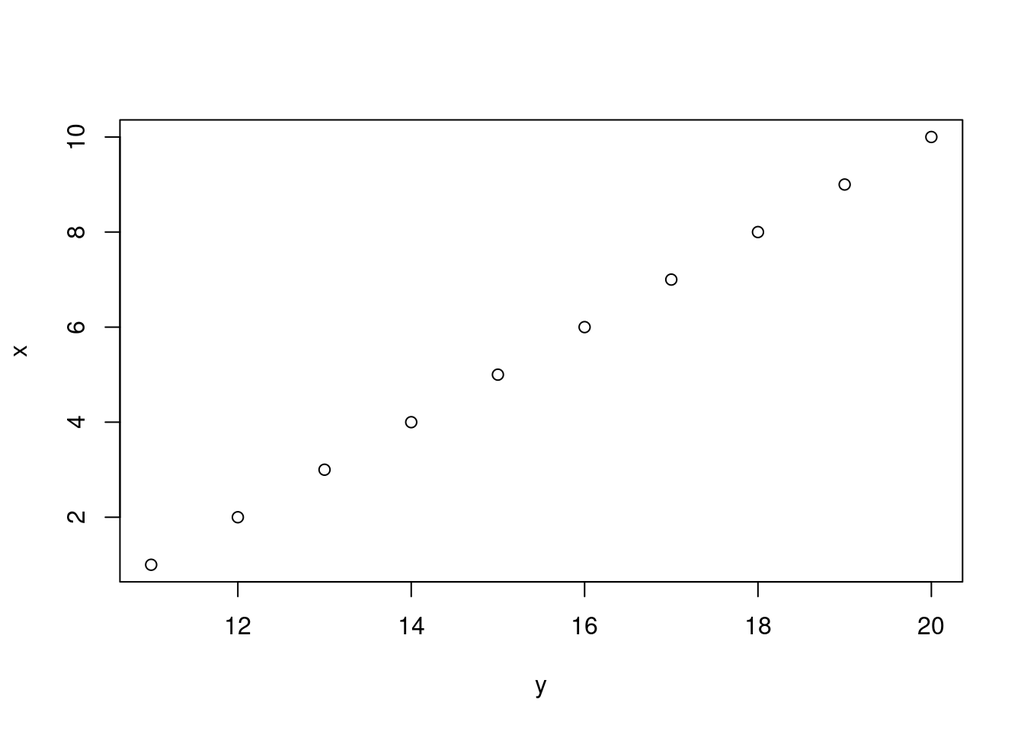

```r
za_graf %$% plot(y, x)
```

Možemo kombinirati različite pipe. Na primjer:

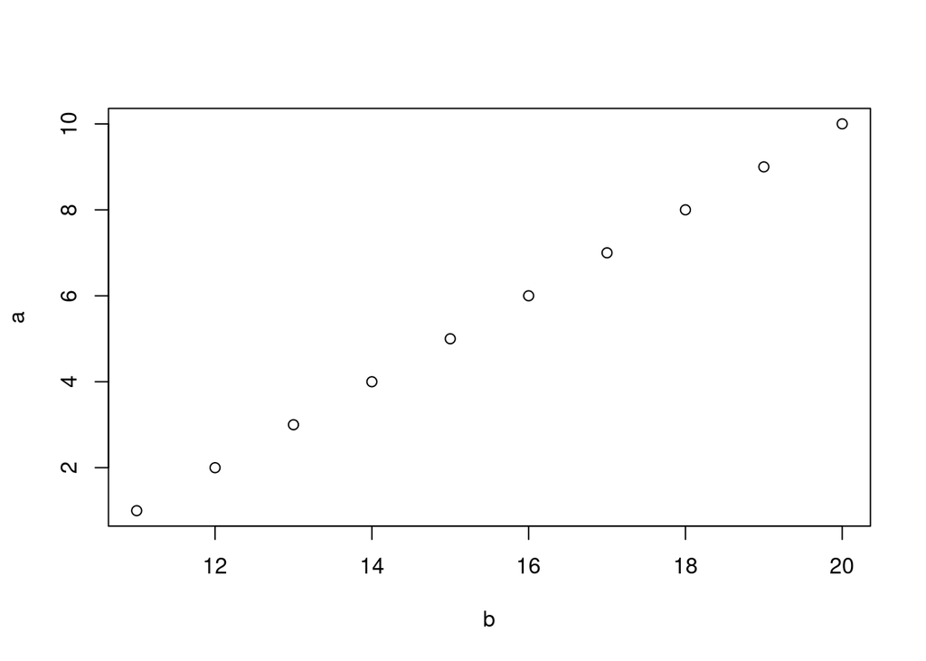

```r
1:10 %>% data.frame (a = ., b = 11:20) %$% plot(b, a)
```

U gornjem primjeru bi nam možda bilo zgodno da možemo pogledati strukturu `data.framea` nakon što ga stvorimo ili napraviti još neke operacije nakon što plotamo varijable.

Imamo pipu i za to.

### %T>%

T-pipa (izvorno *tee*) vraća izraz s lijeve strane umjesto izraza s desne strane. Zbog toga, možemo učiniti sljedeće:

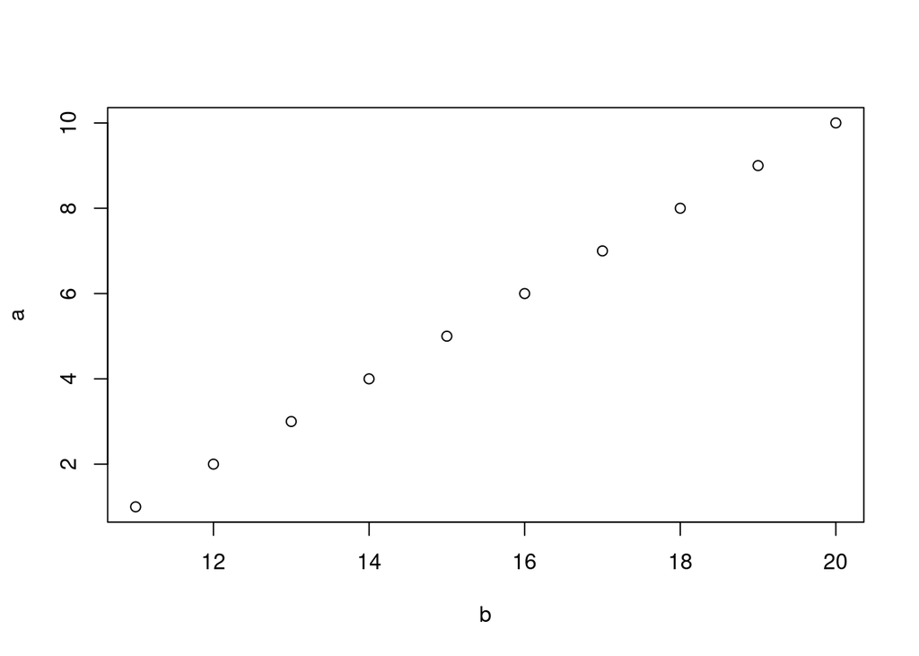

```r
1:10 %>% data.frame(a = ., b = 11:20) %T>% str(.) %$% plot(b, a)
## 'data.frame':    10 obs. of  2 variables:
##  $ a: int  1 2 3 4 5 6 7 8 9 10
##  $ b: int  11 12 13 14 15 16 17 18 19 20
```

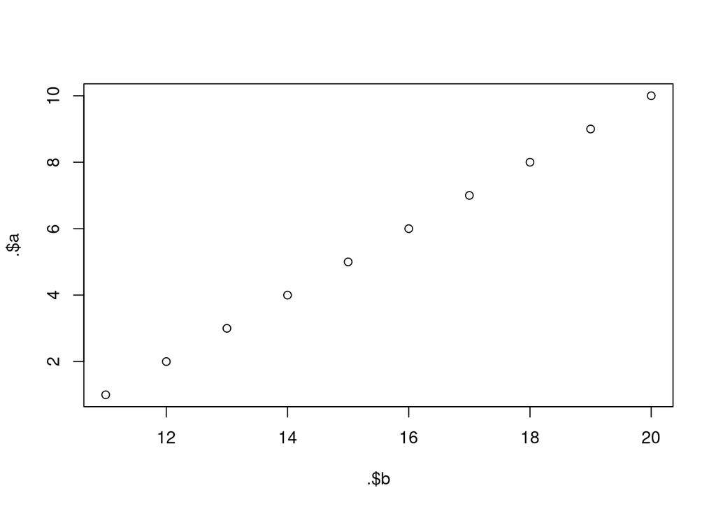

```
## [1] 210
```

```r
1:10 %>% data.frame(a = ., b = 11:20) %T>%
{plot(.$b, .$a)} %$%
sum(a,b)
```

Preostaje nam još jedna pipa…

### %<>%

`%<>%` je *assignment* pipa. Ona istovremeno daje vrijednost s lijeve strane za argument i piše u nju. To nam omogućuje da neku varijablu provučemo kroz seriju transformacijskih koraka i da te transformacije odmah pohranimo.

```r
str(za_graf)
## 'data.frame':    10 obs. of  2 variables:
##  $ x: int  1 2 3 4 5 6 7 8 9 10
##  $ y: int  11 12 13 14 15 16 17 18 19 20

za_graf$x %<>% magrittr::add(., 2) %>%
magrittr::multiply_by(., 2) %>% sqrt(.)

str(za_graf)
## 'data.frame':    10 obs. of  2 variables:
##  $ x: num  2.45 2.83 3.16 3.46 3.74 ...
##  $ y: int  11 12 13 14 15 16 17 18 19 20
```

Ovime završavamo upoznavanje s pipama. Nakratko se vraćamo natrag na primjer s funkcijom `describe`, nakon čega ponovno odlazimo u uzbudljivu digresiju.

## dplyr::select i dplyr::filter

Sad ćemo prikazati deskriptivnu statistiku za pitanja koja tvore jednu od skala koja se nalazi u našim podacima - skalu internalizacije moralnog identiteta - samo na poduzorku žena. Sve varijable koje se odnose na tu skalu imaju ime oblika `moralIdentityInternalization<broj-pitanja>`. Zbog tog sustavnog imenovanja, ne moramo ispisivati imena (ili redne brojeve) svih varijabli koje želimo zahvatiti funkcijom `describe`, nego možemo pozvati funkciju `contains` unutar funkcije `select`. `contains` na omogućuje da odaberemo samo one varijable koje sadrže zadani string.

```r
podaci %>%
dplyr::filter(., pi_gender == 'Female') %>%
dplyr::select(., dplyr::contains('internal',
                                # ignore.case govori treba li
                                # poštivati ili ignorirati
                                # malo/veliko slovo
                                ignore.case = T)) %T>% str(.) %>%
psych::describe(.) %>% print(.)
## Classes 'spec_tbl_df', 'tbl_df', 'tbl' and 'data.frame': 45 obs. of  5 variables:
##  $ moralIdentityInternalization01: num  4 5 5 4 4 5 4 6 6 5 ...
##  $ moralIdentityInternalization02: num  3 5 5 3 3 3 3 5 6 3 ...
##  $ moralIdentityInternalization03: num  1 1 1 1 1 1 1 1 1 1 ...
##  $ moralIdentityInternalization04: num  2 3 1 2 4 2 2 1 1 2 ...
##  $ moralIdentityInternalization05: num  4 5 5 4 2 4 4 6 6 5 ...
##                                vars  n mean   sd median trimmed  mad min
## moralIdentityInternalization01    1 45 4.71 0.66      5    4.68 0.00   3
## moralIdentityInternalization02    2 45 4.18 1.03      4    4.08 1.48   3
## moralIdentityInternalization03    3 45 1.00 0.00      1    1.00 0.00   1
## moralIdentityInternalization04    4 45 1.49 0.87      1    1.46 1.48   0
## moralIdentityInternalization05    5 45 4.49 0.92      4    4.51 1.48   2
##                                max range  skew kurtosis   se
## moralIdentityInternalization01   6     3 -0.09    -0.26 0.10
## moralIdentityInternalization02   7     4  0.63    -0.28 0.15
## moralIdentityInternalization03   1     0   NaN      NaN 0.00
## moralIdentityInternalization04   4     4  0.34     0.20 0.13
## moralIdentityInternalization05   6     4 -0.22    -0.16 0.14

# base R rješenje za usporedbu
str(podaci[podaci$pi_gender == 'Female', c('moralIdentityInternalization01',
                                            'moralIdentityInternalization02',
                                            'moralIdentityInternalization03',
                                            'moralIdentityInternalization04',
                                            'moralIdentityInternalization05')])
## Classes 'tbl_df', 'tbl' and 'data.frame':    45 obs. of  5 variables:
##  $ moralIdentityInternalization01: num  4 5 5 4 4 5 4 6 6 5 ...
##  $ moralIdentityInternalization02: num  3 5 5 3 3 3 3 5 6 3 ...
##  $ moralIdentityInternalization03: num  1 1 1 1 1 1 1 1 1 1 ...
##  $ moralIdentityInternalization04: num  2 3 1 2 4 2 2 1 1 2 ...
##  $ moralIdentityInternalization05: num  4 5 5 4 2 4 4 6 6 5 ...
psych::describe(podaci[podaci$pi_gender == 'Female', c('moralIdentityInternalization01',
                                                        'moralIdentityInternalization02',
                                                        'moralIdentityInternalization03',
                                                        'moralIdentityInternalization04',
                                                        'moralIdentityInternalization05')])
##                                vars  n mean   sd median trimmed  mad min
## moralIdentityInternalization01    1 45 4.71 0.66      5    4.68 0.00   3
## moralIdentityInternalization02    2 45 4.18 1.03      4    4.08 1.48   3
## moralIdentityInternalization03    3 45 1.00 0.00      1    1.00 0.00   1
## moralIdentityInternalization04    4 45 1.49 0.87      1    1.46 1.48   0
## moralIdentityInternalization05    5 45 4.49 0.92      4    4.51 1.48   2
##                                max range  skew kurtosis   se
## moralIdentityInternalization01   6     3 -0.09    -0.26 0.10
## moralIdentityInternalization02   7     4  0.63    -0.28 0.15
## moralIdentityInternalization03   1     0   NaN      NaN 0.00
## moralIdentityInternalization04   4     4  0.34     0.20 0.13
## moralIdentityInternalization05   6     4 -0.22    -0.16 0.14
```

`contains` je jedna od nekoliko pomoćnih funkcija koje su super za `select`. Druge su:

- `starts_with`, koja odabire varijable koje počinju s određenim stringom
- `ends_with`, isto, samo za kraj
- `one_of`, koju treba koristiti kad `selectu` dajemo `character` vektor; na primjer, ako imena varijabli koje želimo zahvatiti spremimo u varijablu
- `matches`, koji nam omogućava da odaberemo varijable čija imena odgovaraju nekom **regularnom izrazu**

## Regularni izrazi

Regularni izrazi (eng. *regular expressions*, *regex* ili *regexp*) su stringovi koji označavaju neki uzorak za pretraživanje. Na primjer, sve ove izraze

```
string
striing
striiing
striiiiiiiiiiiiiiiiing
```

### Kvantifikatori

#### *

Kao što je već rečeno, `*` označava **0 ili više** ponavljanja **znaka** koji mu prethodi. *Znak* se ovdje odnosi na doslovni znak, na klasu znakova ili na grupu znakova. S klasama i grupama ćemo se upoznati malo kasnije. Pogledat ćemo output funkcije `str_detect` koja kao input uzima string (ili više njih) i regularni izraz (`pattern`), a vraća `TRUE` ili `FALSE` ovisno o tome nalazi li se regularni izraz u stringu ili ne.

```r
stringr::str_detect(string = qc(kobilaaaa, maajka, celer), pattern = 'a*') %>% print(.)
## [1] TRUE TRUE TRUE
```

#### +

`+` označava **jedno (1) ili više** ponavljanja prethodnog znaka/klase znakova/grupe znakova. Da vidimo što će nam vratiti funkcija `str_extract_all` koja prima iste argumente kao i `str_detect`, a vraća sve pronađene `patterne`.

```r
stringr::str_extract_all(string = qc(kobilaaaa, maajka, celer), pattern = 'a+') %>% print(.)
## [[1]]
## [1] "aaaa"
##
## [[2]]
## [1] "aa" "a"
##
## [[3]]
## character(0)
```

Postoji i funkcija `str_extract` koja vraća **samo prvi** pronađeni uzorak.

```r
stringr::str_extract(qc(kobilaaaa, maajka, celer), 'a+') %>% print(.)
## [1] "aaaa" "aa"   NA
```

Također, možemo vidjeti da `str_detect` više ne vraća `TRUE` za posljednju riječ.

```r
stringr::str_detect(qc(kobilaaaa, maajka, celer), 'a+') %>% print(.)
## [1]  TRUE  TRUE FALSE
```

#### ?

Upitnik označavao **0 ili jedno (1)** ponavljanje.

```r
qc(kobilaaaa, maajka, celer) %>%
stringr::str_extract_all(., 'a?') %>%
print(.)
## [[1]]
##  [1] ""  ""  ""  ""  ""  "a" "a" "a" "a" ""
##
## [[2]]
## [1] ""  "a" "a" ""  ""  "a" ""
##
## [[3]]
## [1] "" "" "" "" "" ""
```

#### {n,m}

Ova sintaksa nam omogućava da specificiramo koliko ponavljanja želimo. Postoje tri valjane kombinacije:

- `{n,m}` znači od `n` do `m`
- `{n,}` znači `n` ili više
- `{n}` znači točno `n`

`{,m}` **nije valjan** regularni izraz! Također, bitno je da nema razmaka između `n` ili `m` i zareza. Vratit ćemo se na početni primjer.

```r
qc(string, striing, striiing, striiiiiiiiiiiiiiiiing) %>%
stringr::str_extract_all(., 'i{2,5}') %>% print(.)
## [[1]]
## character(0)
##
## [[2]]
## [1] "ii"
##
## [[3]]
## [1] "iii"
##
## [[4]]
## [1] "iiiii" "iiiii" "iiiii" "ii"

qc(string, striing, striiing, striiiiiiiiiiiiiiiiing) %>%
stringr::str_extract_all(., 'i{3,}') %>% print(.)
## [[1]]
## character(0)
##
## [[2]]
## character(0)
##
## [[3]]
## [1] "iii"
##
## [[4]]
## [1] "iiiiiiiiiiiiiiiii"

qc(string, striing, striiing, striiiiiiiiiiiiiiiiing) %>%
stringr::str_extract_all(., 'i{17}') %>% print(.)
## [[1]]
## character(0)
##
## [[2]]
## character(0)
##
## [[3]]
## character(0)
##
## [[4]]
## [1] "iiiiiiiiiiiiiiiii"
```

### Klase znakova

Pretraživanja koja smo dosad vidjeli su jednostavna i jako umjetna. U stvarnim primjenama uglavnom nećemo pokušavati uhvatiti jedno slovo, nego znakove određenog tipa (kao što su brojke) ili određene skupine znakova (npr. brojeve 1, 7 ili 5). U te svrhe, koristimo **klase znakova**.

NB: Klase znakova predstavljaju više mogućih znakova, ali **samo jedno mjesto**. Napravit ćemo mali `data.frame` koji se sastoji od dva stupca koja sadrže stringove.

```r
# ne možemo koristiti qc za mjesta zbog razmaka
data.frame(mjesta = c('Slavonski Brod', 'BJELOVAR', 'Cista Provo', 'Banova Jaruga'),
           tablice = qc(SB1152KF, BJ302LD, CP999LO, BN2001KA)) -> registracije
```

Za početak, pokušat ćemo pronaći sva mjesta čija se imena sastoje od dvije riječi (to znači da ćemo isključiti BJELOVAR `:(`). Vidimo da sva mjesta koja se sastoje od dvije riječi imaju sljedeći uzorak: `[veliko slovo][nekoliko malih slova][razmak][veliko slovo][nekoliko malih slova]`. Koristeći regexe, možemo napraviti sljedeće:

```r
print(registracije)
##           mjesta  tablice
## 1 Slavonski Brod SB1152KF
## 2       BJELOVAR  BJ302LD
## 3    Cista Provo  CP999LO
## 4  Banova Jaruga BN2001KA

registracije$mjesta %>%
stringr::str_detect(., '^[[:upper:]][[:lower:]]+\\s[[:upper:]][[:lower:]]+$')
## [1]  TRUE FALSE  TRUE  TRUE
```

`^` (eng. *caret*) je meta-znak koji označava **početak stringa**. `[[:upper:]]` i `[[:lower:]]` su klase koje označavaju velika odnosno mala slova. `\\s` označava razmak (ostavljanje praznog mjesta također funkcionira). Dakle, obrazac koji tražimo mora počinjati s velikim slovom kojem slijedi jedno ili više malih slova.

Drugi važan meta-znak je `$`, koji označava **kraj stringa**. NB: Ako želimo tražiti same meta-znakove (npr. u `$1551`), ispred njih moramo staviti `\\` (backslash x 2). Taj čin se zove *escaping*.

```r
# qc ni ovdje ne funkcionira
c('$alaj', '€broj') %>%
stringr::str_detect(., '\\$')
## [1]  TRUE FALSE
```

Koristeći uglate zagrade, možemo sami definirati klasu znakova koja je prihvatljiva na nekom mjestu. Na primjer, možemo tražiti sva mjesta koja imaju dvije riječi i čija prva riječ počinje slovom B (velikim!) ili S (također!). Ovdje ćemo koristiti `str_subset`, koja vraća stringove koji sadrže zadani obrazac.

```r
registracije$mjesta %>%
stringr::str_subset(., '^[SB][[:lower:]]+\\s[[:upper:]][[:lower:]]+')
## [1] "Slavonski Brod" "Banova Jaruga"
```

Možemo definirati i custom klasu znakova koji se **ne smiju** nalaziti na nekom mjestu. To radimo tako da na početak svoje klase stavimo znak `^` (`[^...]`).

NB: Ovdje treba obratiti pažnju na pozicioniranje znaka `-`. On mora dolaziti **odmah nakon otvarajuće** zagrade (ili iza `^` ako imamo negacijskju klasu) ili **neposredno prije** zatvarajuće zagrade. Pomoću znaka `-` možemo definirati raspone (npr. `0-9`), pa možemo dobiti error ili nešto neočekivano ako ga stavimo usred klase. Na primjer, možemo tražiti stringove koji ne počinju slovom S ili B:

```r
registracije$mjesta %>%
stringr::str_subset(., '^[^SB].*')
## [1] "Cista Provo"
```

Točka je poseban znak u regularnim izrazima, a označava **bilo koji znak** (osim novog reda, što se u R-u označava s `\\n`). Budući da označava bilo što, `.` se zove *wildcard*. Klasa znakova ima razmjerno puno, pa ćemo spomenuti još jednu koja se često javlja. Pokušat ćemo izvući samo one registracijske oznake (`tablice`) koje imaju tri znamenke.

```r
registracije$tablice %>%
stringr::str_subset(., '[[:upper:]]{2}\\d{3}[[:upper:]]')
## [1] "BJ302LD" "CP999LO"
```

`\\d`, dakle, označava znamenke. Zasad ćemo proći još samo kroz grupe znakova.

### Grupe znakova

Znakove možemo grupirati koristeći obične zagrade (`(...)`). Grupe spajaju znakove u jednu cjelinu. To nam, primjerice, omogućuje da ponavljajuće uzorke lako kvantificiramo.

Na primjer, zamislimo da želimo izvući određene vrste smjehova iz nekih stringova.

```r
qc(hehehe, hehahohohehe, hahahahihi) %>%
stringr::str_extract_all(., '(ha|he){2}') %>%
print(.)
## [[1]]
## [1] "hehe"
##
## [[2]]
## [1] "heha" "hehe"
##
## [[3]]
## [1] "haha"
```

Ovdje smo iskoristili i znak `|` (kod mene se nalazi na `AltGr-W` i zove se *pipe*), koji označava alternaciju, odnosno logičko ILI. Dakle, tražimo dva ponavljanja stringa `ha ili he`.

NB: Ne stavljati razmake oko alternatora jer će se to tumačiti kao razmak koji treba tražiti u stringu!

### Vježbica

Radili smo longitudinalno istraživanje s dvije točke mjerenja. Svojim dragim sudionicima napisali smo jednostavnu formulu za stvaranje šifre: prva dva slova imena majke, posljednje dvije znamenke mobitela i prva dva slova imena rodnog grada.

Sve smo ih stavili u format pogodan za nekakvo analiziranje longitudinalnih podataka, zbog čega se šifre sudionika iz obje točke mjerenja nalaze u jednom stupcu. Ovo su šifre naša 4 sudionika:

```r
sifre <- qc(BR83ZA, KA15ZA, RA75BJ, PE43SP,
            BR83ZG, ZA15KA, RA75BJ, PE43ST)
```

Koristeći moći opažanja, uočili smo da:

- su neki sudionici u drugoj točki mjerenja umjesto prva dva slova imena rodnog grada pisali registarsku oznaku rodnog grada
- je jedan sudionik zamijenio mjesto prvih slova imena majke i prvih slova imena rodnog grada. Pokušajte (i) izvući sve sudionike čiji je rodni grad Zagreb ili Split te (ii) izvući sve šifre sudionika koji je zamijenio redoslijed imena majke i slova rodnog grada. Napišite potpuni regularni izraz (dakle, nema švercanja s `.*`)!

```r
sifre %>%
stringr::str_subset(., '\\w{2}\\d+(ZG|ST|ZA|SP)')
## [1] "BR83ZA" "KA15ZA" "PE43SP" "BR83ZG" "PE43ST"

sifre %>%
stringr::str_subset(., '(ZA|KA)\\d{2}(ZA|KA)')
## [1] "KA15ZA" "ZA15KA"
```

Time završavamo digresivne tokove i bacamo se na borbu s podacima.

## Nastavak pripreme podataka

Zasad smo pogledali strukturu podatka (`str`), kako izgledaju sirovi podaci (`head` i `tail`) te neke statističke sažetke (`describe` i `summary`, `skim`).

Sad ćemo se baciti na formatiranje sirovih podataka u nešto što nam je zgodnije za rad. Prvo ćemo se prisjetiti strukture podatka kojima baratamo.

```r
str(podaci)
## Classes 'spec_tbl_df', 'tbl_df', 'tbl' and 'data.frame': 100 obs. of  64 variables:
##  $ attitudesAndNorms01           : num  5 5 4 6 4 4 6 4 3 5 ...
##  $ attitudesAndNorms02           : num  5 4 6 2 1 4 0 4 7 7 ...
##  $ attitudesAndNorms03           : num  5 2 5 3 2 4 3 5 6 7 ...
##  $ attitudesAndNorms04           : num  5 1 5 2 3 3 3 7 5 6 ...
##  $ attitudesAndNorms05           : num  4 2 3 2 1 4 2 4 4 6 ...
##  $ attitudesAndNorms06           : num  3 2 2 3 2 3 3 3 3 4 ...
##  $ attitudesAndNorms07           : num  4 3 4 5 4 5 6 4 4 5 ...
##  $ attitudesAndNorms08           : num  6 7 5 6 5 5 7 5 3 5 ...
##  $ callToAction                  : num  7 6 7 1 8 7 11 8 3 7 ...
##  $ charitableBehavior01          : num  37 18 7 14 0 37 33 29 16 6 ...
##  $ charitableBehavior02          : num  4 3 3 5 0 2 4 3 2 3 ...
##  $ descriptiveSocialNorms01      : num  4 3 3 1 3 1 2 4 3 4 ...
##  $ descriptiveSocialNorms02      : num  3 1 3 1 1 1 2 3 3 5 ...
##  $ descriptiveSocialNorms03      : num  2 3 2 2 2 3 3 4 4 5 ...
##  $ descriptiveSocialNorms04      : num  2 1 5 3 4 2 2 2 2 4 ...
##  $ mf_AuthoritySubversion        : num  1 1 2 2 2 0 2 1 1 2 ...
##  $ mf_CareHarm                   : num  3 3 3 3 4 3 4 3 3 4 ...
##  $ mf_FairnessCheating           : num  3 3 4 3 2 4 4 5 3 4 ...
##  $ mf_LoyaltyBetrayal            : num  2 2 2 3 2 1 2 0 0 1 ...
##  $ mf_SanctityDegradation        : num  1 1 1 1 1 -1 1 -1 1 1 ...
##  $ moralFoundations01            : num  4 3 4 3 3 4 5 3 4 4 ...
##  $ moralFoundations02            : num  4 3 4 3 1 4 4 4 2 5 ...
##  $ moralFoundations03            : num  3 0 2 1 1 0 2 0 -1 0 ...
##  $ moralFoundations04            : num  1 0 2 2 2 0 2 0 1 2 ...
##  $ moralFoundations05            : num  2 2 1 3 3 -1 3 1 1 2 ...
##  $ moralFoundations06            : num  0 0 0 2 -1 1 0 0 -1 1 ...
##  $ moralFoundations07            : num  4 3 4 4 5 2 4 4 3 4 ...
##  $ moralFoundations08            : num  4 3 4 3 3 4 5 4 3 5 ...
##  $ moralFoundations09            : num  3 3 2 4 3 3 3 1 -1 1 ...
##  $ moralFoundations10            : num  0 -1 1 3 2 0 2 1 1 1 ...
##  $ moralFoundations11            : num  1 3 1 0 1 -1 2 0 3 3 ...
##  $ moralFoundations12            : num  6 5 4 5 4 4 5 4 3 5 ...
##  $ moralFoundations13            : num  3 5 4 5 5 3 4 5 4 5 ...
##  $ moralFoundations14            : num  4 2 1 1 3 3 3 1 3 2 ...
##  $ moralFoundations15            : num  3 2 2 1 2 3 3 2 5 3 ...
##  $ moralFoundations16            : num  3 1 1 2 -1 1 -2 2 0 1 ...
##  $ moralFoundations17            : num  2 5 3 4 4 4 3 4 3 3 ...
##  $ moralFoundations18            : num  2 3 3 4 5 2 4 5 4 4 ...
##  $ moralFoundations19            : num  0 2 4 2 2 2 4 4 4 2 ...
##  $ moralFoundations20            : num  0 1 0 4 1 3 3 3 2 2 ...
##  $ moralFoundations21            : num  0 1 1 1 3 3 1 2 1 -1 ...
##  $ moralFoundations22            : num  4 4 6 4 4 3 5 3 5 5 ...
##  $ moralFoundations23            : num  3 3 4 2 4 0 3 4 3 3 ...
##  $ moralFoundations24            : num  4 3 1 5 2 3 2 6 2 3 ...
##  $ moralFoundations25            : num  0 0 1 2 0 3 1 2 2 1 ...
##  $ moralFoundations26            : num  1 1 1 5 0 2 2 3 1 1 ...
##  $ moralFoundations27            : num  1 1 0 1 1 1 -1 2 0 1 ...
##  $ moralFoundations28            : num  0 -1 2 -1 -1 1 3 1 4 1 ...
##  $ moralFoundations29            : num  1 1 3 2 4 1 4 2 2 0 ...
##  $ moralFoundations30            : num  1 1 1 1 2 1 1 0 2 2 ...
##  $ moralFoundations31            : num  3 2 1 5 2 2 4 3 3 2 ...
##  $ moralFoundations32            : num  1 0 0 4 2 1 0 1 2 1 ...
##  $ moralIdentityInternalization01: num  5 4 6 6 4 4 5 3 6 5 ...
##  $ moralIdentityInternalization02: num  2 3 5 4 3 6 5 2 4 5 ...
##  $ moralIdentityInternalization03: num  1 1 1 1 1 1 1 1 1 1 ...
##  $ moralIdentityInternalization04: num  2 3 1 3 2 1 3 3 3 1 ...
##  $ moralIdentityInternalization05: num  3 4 5 4 4 4 5 3 4 5 ...
##  $ pi_age                        : num  3 20 20 19 22 25 23 41 16 17 ...
##  $ pi_education                  : chr  "Some professional diploma, no degree" "Master's degree" "High school" "Master's degree" ...
##  $ pi_gender                     : chr  "Male" "Male" "Male" "Male" ...
##  $ pi_ideology                   : chr  "Neither liberal or conservative" "Very liberal (left)" "Neither liberal or conservative" "Very liberal (left)" ...
##  $ pi_income                     : chr  "Somewhat below the average" "Somewhat above the average" "Somewhat above the average" "Somewhat above the average" ...
##  $ pi_nationality                : chr  "American" "USA" "Turkish" "United States of America" ...
##  $ pi_previousDonations          : chr  "Rarely" "Regularly" "Rarely" "Rarely" ...
```

Za početak, iskoristit ćemo moći opažanja i primijetiti da su varijable koje počinju s `pi` (osim `pi_age`) spremljene kao `character` vektori. Taj tip vrijednosti nije zgodan za većinu obrada koje bismo mogli htjeti raditi i razlog je zašto nam `summary` vraća nekoristan sažetak.

### Baratanje kategoričkim varijablama

Stoga, pretvorit ćemo te varijable iz `charactera` u `factore`. Varijable možemo modificirati koristeći `mutate` obitelj funkcija. Ovdje ćemo iskoristiti `mutate_at`, koji nam omogućuje da specificiramo varijable na koje želimo primijeniti neku funkciju.

Uhvatit ćemo sve `pi` varijable osim `pi_age` te na njih primijeniti funkciju `as.factor`, koja će ih pretvoriti u `factore`. Budući da će `mutate_at` zadanu funkciju primijeniti na postojeće stupce, dobro je (a) uvjeriti se da biramo prave stupce i (b) uvjeriti se da radimo ono što želimo raditi prije nego što spremimo promjene. (a) ćemo riješiti koristeći `colnames` i `select`.

```r
podaci %>%
dplyr::select(., dplyr::starts_with('pi'), -pi_age) %>%
colnames(.)
## [1] "pi_education"         "pi_gender"            "pi_ideology"
## [4] "pi_income"            "pi_nationality"       "pi_previousDonations"
```

Vidimo da ciljamo ispravne stupce. Sad možemo eksperimentirati s `mutate_at`.

```r
podaci %>%
dplyr::mutate_at(.,
                # varijable koje želimo zahvatiti treba omotati u
                # funkciju vars; ona prima iste pomoćne funkcije kao
                # i select
                .vars = dplyr::vars(dplyr::starts_with('pi'), -pi_age),
                .fun = as.factor) %>%
# ovaj dio je samo radi prikazivanja
dplyr::select(., starts_with('pi')) %>%
str(.)
## Classes 'spec_tbl_df', 'tbl_df', 'tbl' and 'data.frame': 100 obs. of  7 variables:
##  $ pi_age              : num  3 20 20 19 22 25 23 41 16 17 ...
##  $ pi_education        : Factor w/ 6 levels "Elementary School",..: 5 3 2 3 3 3 5 3 6 5 ...
##  $ pi_gender           : Factor w/ 2 levels "Female","Male": 2 2 2 2 1 2 1 2 2 1 ...
##  $ pi_ideology         : Factor w/ 7 levels "Extremely conservative (right)",..: 3 7 3 7 7 7 5 5 3 7 ...
##  $ pi_income           : Factor w/ 5 levels "About the average",..: 5 4 4 4 4 4 4 4 4 5 ...
##  $ pi_nationality      : Factor w/ 16 levels "American","Asian american",..: 1 15 9 12 13 15 1 14 7 5 ...
##  $ pi_previousDonations: Factor w/ 4 levels "Never","Often",..: 3 4 3 3 4 4 4 2 2 3 ...
```

Zadovoljni smo outputom, pa možemo malko modificirati kod i spremiti promjene.

```r
podaci %<>%
dplyr::mutate_at(.,
                .vars = dplyr::vars(dplyr::starts_with('pi'), -pi_age),
                .fun = as.factor)

str(podaci)
## Classes 'spec_tbl_df', 'tbl_df', 'tbl' and 'data.frame': 100 obs. of  64 variables:
##  $ attitudesAndNorms01           : num  5 5 4 6 4 4 6 4 3 5 ...
##  $ attitudesAndNorms02           : num  5 4 6 2 1 4 0 4 7 7 ...
##  $ attitudesAndNorms03           : num  5 2 5 3 2 4 3 5 6 7 ...
##  $ attitudesAndNorms04           : num  5 1 5 2 3 3 3 7 5 6 ...
##  $ attitudesAndNorms05           : num  4 2 3 2 1 4 2 4 4 6 ...
##  $ attitudesAndNorms06           : num  3 2 2 3 2 3 3 3 3 4 ...
##  $ attitudesAndNorms07           : num  4 3 4 5 4 5 6 4 4 5 ...
##  $ attitudesAndNorms08           : num  6 7 5 6 5 5 7 5 3 5 ...
##  $ callToAction                  : num  7 6 7 1 8 7 11 8 3 7 ...
##  $ charitableBehavior01          : num  37 18 7 14 0 37 33 29 16 6 ...
##  $ charitableBehavior02          : num  4 3 3 5 0 2 4 3 2 3 ...
##  $ descriptiveSocialNorms01      : num  4 3 3 1 3 1 2 4 3 4 ...
##  $ descriptiveSocialNorms02      : num  3 1 3 1 1 1 2 3 3 5 ...
##  $ descriptiveSocialNorms03      : num  2 3 2 2 2 3 3 4 4 5 ...
##  $ descriptiveSocialNorms04      : num  2 1 5 3 4 2 2 2 2 4 ...
##  $ mf_AuthoritySubversion        : num  1 1 2 2 2 0 2 1 1 2 ...
##  $ mf_CareHarm                   : num  3 3 3 3 4 3 4 3 3 4 ...
##  $ mf_FairnessCheating           : num  3 3 4 3 2 4 4 5 3 4 ...
##  $ mf_LoyaltyBetrayal            : num  2 2 2 3 2 1 2 0 0 1 ...
##  $ mf_SanctityDegradation        : num  1 1 1 1 1 -1 1 -1 1 1 ...
##  $ moralFoundations01            : num  4 3 4 3 3 4 5 3 4 4 ...
##  $ moralFoundations02            : num  4 3 4 3 1 4 4 4 2 5 ...
##  $ moralFoundations03            : num  3 0 2 1 1 0 2 0 -1 0 ...
##  $ moralFoundations04            : num  1 0 2 2 2 0 2 0 1 2 ...
##  $ moralFoundations05            : num  2 2 1 3 3 -1 3 1 1 2 ...
##  $ moralFoundations06            : num  0 0 0 2 -1 1 0 0 -1 1 ...
##  $ moralFoundations07            : num  4 3 4 4 5 2 4 4 3 4 ...
##  $ moralFoundations08            : num  4 3 4 3 3 4 5 4 3 5 ...
##  $ moralFoundations09            : num  3 3 2 4 3 3 3 1 -1 1 ...
##  $ moralFoundations10            : num  0 -1 1 3 2 0 2 1 1 1 ...
##  $ moralFoundations11            : num  1 3 1 0 1 -1 2 0 3 3 ...
##  $ moralFoundations12            : num  6 5 4 5 4 4 5 4 3 5 ...
##  $ moralFoundations13            : num  3 5 4 5 5 3 4 5 4 5 ...
##  $ moralFoundations14            : num  4 2 1 1 3 3 3 1 3 2 ...
##  $ moralFoundations15            : num  3 2 2 1 2 3 3 2 5 3 ...
##  $ moralFoundations16            : num  3 1 1 2 -1 1 -2 2 0 1 ...
##  $ moralFoundations17            : num  2 5 3 4 4 4 3 4 3 3 ...
##  $ moralFoundations18            : num  2 3 3 4 5 2 4 5 4 4 ...
##  $ moralFoundations19            : num  0 2 4 2 2 2 4 4 4 2 ...
##  $ moralFoundations20            : num  0 1 0 4 1 3 3 3 2 2 ...
##  $ moralFoundations21            : num  0 1 1 1 3 3 1 2 1 -1 ...
##  $ moralFoundations22            : num  4 4 6 4 4 3 5 3 5 5 ...
##  $ moralFoundations23            : num  3 3 4 2 4 0 3 4 3 3 ...
##  $ moralFoundations24            : num  4 3 1 5 2 3 2 6 2 3 ...
##  $ moralFoundations25            : num  0 0 1 2 0 3 1 2 2 1 ...
##  $ moralFoundations26            : num  1 1 1 5 0 2 2 3 1 1 ...
##  $ moralFoundations27            : num  1 1 0 1 1 1 -1 2 0 1 ...
##  $ moralFoundations28            : num  0 -1 2 -1 -1 1 3 1 4 1 ...
##  $ moralFoundations29            : num  1 1 3 2 4 1 4 2 2 0 ...
##  $ moralFoundations30            : num  1 1 1 1 2 1 1 0 2 2 ...
##  $ moralFoundations31            : num  3 2 1 5 2 2 4 3 3 2 ...
##  $ moralFoundations32            : num  1 0 0 4 2 1 0 1 2 1 ...
##  $ moralIdentityInternalization01: num  5 4 6 6 4 4 5 3 6 5 ...
##  $ moralIdentityInternalization02: num  2 3 5 4 3 6 5 2 4 5 ...
##  $ moralIdentityInternalization03: num  1 1 1 1 1 1 1 1 1 1 ...
##  $ moralIdentityInternalization04: num  2 3 1 3 2 1 3 3 3 1 ...
##  $ moralIdentityInternalization05: num  3 4 5 4 4 4 5 3 4 5 ...
##  $ pi_age                        : num  3 20 20 19 22 25 23 41 16 17 ...
##  $ pi_education                  : Factor w/ 6 levels "Elementary School",..: 5 3 2 3 3 3 5 3 6 5 ...
##  $ pi_gender                     : Factor w/ 2 levels "Female","Male": 2 2 2 2 1 2 1 2 2 1 ...
##  $ pi_ideology                   : Factor w/ 7 levels "Extremely conservative (right)",..: 3 7 3 7 7 7 5 5 3 7 ...
##  $ pi_income                     : Factor w/ 5 levels "About the average",..: 5 4 4 4 4 4 4 4 4 5 ...
##  $ pi_nationality                : Factor w/ 16 levels "American","Asian american",..: 1 15 9 12 13 15 1 14 7 5 ...
##  $ pi_previousDonations          : Factor w/ 4 levels "Never","Often",..: 3 4 3 3 4 4 4 2 2 3 ...
```

Ako sad pozovemo `summary`, dobit ćemo korisnije rezultate.

```r
podaci %>%
dplyr::select(., dplyr::starts_with('pi_'), -pi_age) %>%
summary(.)
##                                pi_education  pi_gender
##  Elementary School                   : 1    Female:45
##  High school                         :23    Male  :55
##  Master's degree                     :24
##  PhD or higher                       : 1
##  Some professional diploma, no degree:19
##  The baccalaureate                   :32
##
##                           pi_ideology                      pi_income
##  Extremely conservative (right) : 1   About the average         :17
##  Extremely liberal (left)       :17   Much above the average    : 9
##  Neither liberal or conservative:12   Much below the average    : 8
##  Somewhat conservative (right)  :10   Somewhat above the average:47
##  Somewhat liberal (left)        :24   Somewhat below the average:19
##  Very conservative (right)      : 2
##  Very liberal (left)            :34
##                   pi_nationality pi_previousDonations
##  American                :24     Never    : 8
##  USA                     :24     Often    :31
##  Canadian                :13     Rarely   :40
##  British                 :11     Regularly:21
##  United States           : 9
##  united states of america: 3
##  (Other)                 :16
```

Gledajući output ove funkcije, primjećujemo da su pojedine vrijednosti prilično dugačke (npr. Some professional diploma, no degree). Koristeći `forcats` paket (dio `tidyversea`), vrlo lako možemo rekodirati te vrijednosti. Za početak, da bismo si uskratili nešto tipkanja, možemo pozvati funkciju `dput` kako bismo dobili reprezentaciju razina faktora koju možemo kopipejstati.

```r
podaci$pi_education %>% levels(.) %>% dput(.)
## c("Elementary School", "High school", "Master's degree", "PhD or higher",
## "Some professional diploma, no degree", "The baccalaureate")

podaci$pi_education %>%
head(., 10) %T>% print(.) %>%
forcats::fct_recode(., 'elem-sch' = "Elementary School", 'hi-sch' = "High school",
                    'masters' = "Master's degree", 'phd' = "PhD or higher",
                    'prof-dip' = "Some professional diploma, no degree",
                    'bac' = "The baccalaureate") %>% print(.)
##  [1] Some professional diploma, no degree
##  [2] Master's degree
##  [3] High school
##  [4] Master's degree
##  [5] Master's degree
##  [6] Master's degree
##  [7] Some professional diploma, no degree
##  [8] Master's degree
##  [9] The baccalaureate
## [10] Some professional diploma, no degree
## 6 Levels: Elementary School High school Master's degree ... The baccalaureate
##  [1] prof-dip masters  hi-sch   masters  masters  masters  prof-dip
##  [8] masters  bac      prof-dip
## Levels: elem-sch hi-sch masters phd prof-dip bac
```

Kratko pojašnjenje: uzimamo samo varijablu `pi_education` te prvih 10 unosa (`head`). Usput pozivamo `print` (s T-pipom!) kako bismo ispisali izvornih 10 vrijednosti. Varijablu s tih 10 vrijednosti šaljemo u `fct_recode`, gdje rekodiramo razine. Naposljetku, pozivamo `print` kako bismo ispisali nove vrijednosti (`print` ovdje nije potreban, tu je samo zato da bi se output izjednačio onom koji dobivamo nakon prvog poziva; to je specifičnost Jupyter Notebooka). Sad kad smo zadovoljni outputom, možemo maknuti nepotrebne dijelove i upisati promjenu.

```r
podaci$pi_education %<>%
forcats::fct_recode(., 'elem-sch' = "Elementary School", 'hi-sch' = "High school",
                    'masters' = "Master's degree", 'phd' = "PhD or higher",
                    'prof-dip' = "Some professional diploma, no degree",
                    'bac' = "The baccalaureate")

levels(podaci$pi_education)
## [1] "elem-sch" "hi-sch"   "masters"  "phd"      "prof-dip" "bac"
```

### Vježba

Pokušajte napraviti isto s varijablom `pi_income`.

Rekodirajte razine tako da `avg` označava `About the average`, a razine ispod i iznad toga označite dodavanjem odgovarajućeg broja minusa odnosno pluseva na kraj (npr. `avg-` ili `avg++`).

```r
podaci$pi_income %>% levels(.) %>% dput(.)
## c("About the average", "Much above the average", "Much below the average",
## "Somewhat above the average", "Somewhat below the average")

podaci$pi_income %<>%
forcats::fct_recode(., 'avg' = "About the average",
                    'avg++' = "Much above the average",
                    'avg--' = "Much below the average",
                    'avg+' = "Somewhat above the average",
                    'avg-' = "Somewhat below the average")
```

Ovdje možemo primijetiti da je redoslijed razina podosta besmislen, tako da ćemo ih izvrtiti tako da idu od najniže do najviše. To ćemo učiniti pomoću funkcije `fct_relevel`.

```r
podaci$pi_income %>%
forcats::fct_relevel(., 'avg--', 'avg-', 'avg', 'avg+', 'avg++') %>%
# još ćemo faktor pretvoriti u ordered
factor(., ordered = T) %>%
tail(., 10) %>% print(.)
##  [1] avg-- avg-  avg-  avg-  avg+  avg   avg++ avg+  avg-  avg+
## Levels: avg-- < avg- < avg < avg+ < avg++

podaci$pi_income %<>%
forcats::fct_relevel(., 'avg--', 'avg-', 'avg', 'avg+', 'avg++') %>%
factor(., ordered = T)

str(podaci$pi_income)
##  Ord.factor w/ 5 levels "avg--"<"avg-"<..: 2 4 4 4 4 4 4 4 4 2 ...
```

Nećemo prolaziti kroz rekodiranje svih faktora, ali hoćemo proći kroz rekodiranje nacionalnosti, zato jer nam to daje mogućnost da se igramo sa stringovima i regularnim izrazima.

### Kodiranje nacionalnosti (pitanje otvorenog tipa)

Pitanje o nacionalnosti bilo je otvorenog tipa, tako da ista nacionalnost može biti reprezentirana na različite načine.

```r
podaci$pi_nationality %>% head(.)
## [1] American                 USA
## [3] Turkish                  United States of America
## [5] US                       USA
## 16 Levels: American Asian american Australian British Canadian ... White
```

Već u prvih 6 unosa vidimo da se javljaju “US”, “USA”, “United States of America” te “American”, što sve označava istu nacionalnost. Koristeći regularne izraze i funkciju `case_when`, lako možemo grupirati različite unose. Za početak, iskoristit ćemo funkciju `tolower` kako bismo sve stringove pretvorili u mala slova (tako da ne moramo paziti na to da su “american” i “American” različiti unosi) te funkciju `str_trim`, koja će ukloniti razmake s početka i kraja stringova (jer je moguće da je netko unio “American”, a netko “American”).

```r
podaci$pi_nationality %<>% tolower(.) %>% stringr::str_trim(.)

head(podaci$pi_nationality)
## [1] "american"                 "usa"
## [3] "turkish"                  "united states of america"
## [5] "us"                       "usa"
```

Ok. Za početak, možemo pozvati `table` da dobijemo pregled frekvencija po faktorima, te `sort` kako bismo ih poredali od najučestalijih do najrjeđih.

```r
table(podaci$pi_nationality) %>% sort(., decreasing = T)
##
##                      usa                 american                 canadian
##                       26                       24                       13
##                  british            united states united states of america
##                       11                        9                        5
##               australian                   french               seychelles
##                        2                        2                        2
##                       us           asian american                    dutch
##                        2                        1                        1
##                  turkish                    white
##                        1                        1
```

Budući da ovdje imamo samo 100 sudionika i razmjerno malo različitih nacionalnosti, rekodiranje je lako. Za kodiranje nacionalnosti koristit ćemo funkciju `case_when`, koja nam omogućuje da specificiramo neki logički izraz (dakle, nešto što kao rezultat vraća `TRUE` ili `FALSE`) i akciju koju treba napraviti u `TRUE` slučaju. `case_when` za argumente prima logičke izraze i akcije odvojene tildom (`~`), pa pozivanje funkcije izgleda ovako:

```
case_when(logički-izraz ~ akcija-ako-TRUE,
          logički-izraz-2 ~ akcija-ako-TRUE-2)
```

```r
podaci$pi_nationality %>%
# case_when ovdje moramo obaviti u {} jer inače dobijemo error
{dplyr::case_when(stringr::str_detect(., 'usa?|american|united states.*|\\w+ americ') ~ 'american',
           str_detect(., 'dutch|french') ~ 'fr-nl',
           str_detect(., 'seychelles|turkish|white') ~ 'other',
           # akciju u svim nespecificiranim slučajevima određujemo
           # tako da stavimo TRUE ~ akcija. ovdje kao akciju stavljamo
           # točku, što znači da taj unos treba ostaviti onakvim
           # kakav je
           TRUE ~ .)} %>% table(.)
## .
## american  british canadian    fr-nl    other
##       69       11       13        3        4

podaci$pi_nationality %<>%
{dplyr::case_when(stringr::str_detect(., 'usa?|american|united states.*|\\w+ americ') ~ 'american',
           str_detect(., 'dutch|french') ~ 'fr-nl',
           str_detect(., 'seychelles|turkish|white') ~ 'other',
           TRUE ~ .)}
```

### Preimenovanje varijabli

Nekad su imena varijabli jako nezgrapna, neinformativna, mutava i slično. Budući da ćete se prije ili poslije susresti s takvim imenima, proći ćemo kroz nekoliko načina za mijenjanje imena varijabli. Ako želimo promijeniti imena manjeg broja varijabli, možemo koristiti funkciju `rename`. Na primjer, varijable `charitableBehavior01` i `charitableBehavior02` ne govore ništa o tome što su. Jedna je namjera doniranja novca, a druga namjera doniranja vremena. Stoga, preimenovat ćemo ih u `donationMoney` i `donationTime`.

```r
podaci %>%
dplyr::select(10:11) %>%
colnames(.)
## [1] "charitableBehavior01" "charitableBehavior02"

podaci %<>%
dplyr::rename(., donationMoney = charitableBehavior01,
      donationTime = charitableBehavior02)

podaci %>%
dplyr::select(10:11) %>%
colnames(.)
## [1] "donationMoney" "donationTime"
```

Ako trebamo preimenovati veći broj varijabli i ako smo te sreće da njihova imena možemo uhvatiti regularnim izrazima, možemo koristiti `str_replace`. Na primjer, imamo 32 varijable koje se zovu `moralFoundationsXX` i koje predstavljaju pitanja na Moral Foundations Questionnaireu. MFQ se sastoji od 5 faktora (authority, care, loyalty, fairness, sanctity) - svaki faktor reprezentiran je sa 6 pitanja. Osim toga, ima i dvije kontrolne čestice. Preimenovat ćemo varijable tako da na kraj imena svake od njih dodamo oznaku faktora kojoj pripada. Za to ćemo koristiti funkciju `str_replace`, koja nam omogućuje da neki obrazac definiran regexom zamijenimo nekim drugim stringom.

```r
qc(orahovica, orašar) %>%
stringr::str_replace(., 'ora(h|š)', 'bor')
## [1] "borovica" "borar"
```

Sad ćemo vidjeti kako ovu funkciju možemo koristiti za preimenovati varijable.

```r
# dohvaćamo imena stupaca
colnames(podaci) %>%
# specificiramo stupce na kojima želimo izvršiti zamjenu
stringr::str_replace(., pattern = '(moralFoundations)(01|07|12|17|23|28)',
                     replacement = '\\1\\2_care') %>%
# ovo je samo radi prikazivanja svih MFQ pitanja
stringr::str_subset(., 'moralFoundations') %>% print(.)
##  [1] "moralFoundations01_care" "moralFoundations02"
##  [3] "moralFoundations03"      "moralFoundations04"
##  [5] "moralFoundations05"      "moralFoundations06"
##  [7] "moralFoundations07_care" "moralFoundations08"
##  [9] "moralFoundations09"      "moralFoundations10"
## [11] "moralFoundations11"      "moralFoundations12_care"
## [13] "moralFoundations13"      "moralFoundations14"
## [15] "moralFoundations15"      "moralFoundations16"
## [17] "moralFoundations17_care" "moralFoundations18"
## [19] "moralFoundations19"      "moralFoundations20"
## [21] "moralFoundations21"      "moralFoundations22"
## [23] "moralFoundations23_care" "moralFoundations24"
## [25] "moralFoundations25"      "moralFoundations26"
## [27] "moralFoundations27"      "moralFoundations28_care"
## [29] "moralFoundations29"      "moralFoundations30"
## [31] "moralFoundations31"      "moralFoundations32"
```

Vidimo da pitanja koja smo odredili sada imaju sufiks `_care`. U `replacement` argumentu smo iskoristili mogućnost referenciranja koju nam nudi grupiranje znakova u regularnim izrazima. Počevši s lijeva, svaku grupu definiranu pomoću `(...)` možemo dohvatiti pomoću `\\n`, gdje `n` označava redni broj grupe. Dakle, u gornjem primjeru se pri izvršavanju zamjene `\\1` širi u prvu pronađenu grupu (moralFoundations), a `\\2` u drugu pronađenu grupu (01, 07, 12, 17, 23 ili 28, ovisno o tome što je u pojedinom stringu pronađeno). Time dobivamo `moralFoundations01_care`, `moralFoundations07_care` itd. Kod ovakvog mijenjanja imena je zgodno to što nam se svaki put vraćaju imena svih stupaca - ako u imenu nekog stupca nije pronađen uzorak koji smo specificirali u `pattern`, ono ostaje netaknuto. Zbog toga, možemo napraviti lanac poziva `str_replace` pomoću pipa.

```r
colnames(podaci) %>%
    stringr::str_replace(., '(moralFoundations)(01|07|12|17|23|28)', '\\1\\2_care') %>%
    str_replace(., '(moralFoundations)(02|08|13|18|24|29)', '\\1\\2_fair') %>%
    str_replace(., '(moralFoundations)(03|09|14|19|25|30)', '\\1\\2_loyal') %>%
    str_replace(., '(moralFoundations)(04|10|15|20|26|31)', '\\1\\2_author') %>%
    str_replace(., '(moralFoundations)(05|11|16|21|27|32)', '\\1\\2_sanct') %>%
    str_replace(., '(moralFoundations)(06|22)', '\\1\\2_control') %>%
print(.)
##  [1] "attitudesAndNorms01"            "attitudesAndNorms02"
##  [3] "attitudesAndNorms03"            "attitudesAndNorms04"
##  [5] "attitudesAndNorms05"            "attitudesAndNorms06"
##  [7] "attitudesAndNorms07"            "attitudesAndNorms08"
##  [9] "callToAction"                   "donationMoney"
## [11] "donationTime"                   "descriptiveSocialNorms01"
## [13] "descriptiveSocialNorms02"       "descriptiveSocialNorms03"
## [15] "descriptiveSocialNorms04"       "mf_AuthoritySubversion"
## [17] "mf_CareHarm"                    "mf_FairnessCheating"
## [19] "mf_LoyaltyBetrayal"             "mf_SanctityDegradation"
## [21] "moralFoundations01_care"        "moralFoundations02_fair"
## [23] "moralFoundations03_loyal"       "moralFoundations04_author"
## [25] "moralFoundations05_sanct"       "moralFoundations06_control"
## [27] "moralFoundations07_care"        "moralFoundations08_fair"
## [29] "moralFoundations09_loyal"       "moralFoundations10_author"
## [31] "moralFoundations11_sanct"       "moralFoundations12_care"
## [33] "moralFoundations13_fair"        "moralFoundations14_loyal"
## [35] "moralFoundations15_author"      "moralFoundations16_sanct"
## [37] "moralFoundations17_care"        "moralFoundations18_fair"
## [39] "moralFoundations19_loyal"       "moralFoundations20_author"
## [41] "moralFoundations21_sanct"       "moralFoundations22_control"
## [43] "moralFoundations23_care"        "moralFoundations24_fair"
## [45] "moralFoundations25_loyal"       "moralFoundations26_author"
## [47] "moralFoundations27_sanct"       "moralFoundations28_care"
## [49] "moralFoundations29_fair"        "moralFoundations30_loyal"
## [51] "moralFoundations31_author"      "moralFoundations32_sanct"
## [53] "moralIdentityInternalization01" "moralIdentityInternalization02"
## [55] "moralIdentityInternalization03" "moralIdentityInternalization04"
## [57] "moralIdentityInternalization05" "pi_age"
## [59] "pi_education"                   "pi_gender"
## [61] "pi_ideology"                    "pi_income"
## [63] "pi_nationality"                 "pi_previousDonations"
```

Kad smo sigurni da dobivamo ono što očekujemo, samo promijenimo pipu `%>%` u `%<>%`.

```r
colnames(podaci) %<>%
    str_replace(., '(moralFoundations)(01|07|12|17|23|28)', '\\1\\2_care') %>%
    str_replace(., '(moralFoundations)(02|08|13|18|24|29)', '\\1\\2_fair') %>%
    str_replace(., '(moralFoundations)(03|09|14|19|25|30)', '\\1\\2_loyal') %>%
    str_replace(., '(moralFoundations)(04|10|15|20|26|31)', '\\1\\2_author') %>%
    str_replace(., '(moralFoundations)(05|11|16|21|27|32)', '\\1\\2_sanct') %>%
    str_replace(., '(moralFoundations)(06|22)', '\\1\\2_control')

colnames(podaci) %>% print(.)
##  [1] "attitudesAndNorms01"            "attitudesAndNorms02"
##  [3] "attitudesAndNorms03"            "attitudesAndNorms04"
##  [5] "attitudesAndNorms05"            "attitudesAndNorms06"
##  [7] "attitudesAndNorms07"            "attitudesAndNorms08"
##  [9] "callToAction"                   "donationMoney"
## [11] "donationTime"                   "descriptiveSocialNorms01"
## [13] "descriptiveSocialNorms02"       "descriptiveSocialNorms03"
## [15] "descriptiveSocialNorms04"       "mf_AuthoritySubversion"
## [17] "mf_CareHarm"                    "mf_FairnessCheating"
## [19] "mf_LoyaltyBetrayal"             "mf_SanctityDegradation"
## [21] "moralFoundations01_care"        "moralFoundations02_fair"
## [23] "moralFoundations03_loyal"       "moralFoundations04_author"
## [25] "moralFoundations05_sanct"       "moralFoundations06_control"
## [27] "moralFoundations07_care"        "moralFoundations08_fair"
## [29] "moralFoundations09_loyal"       "moralFoundations10_author"
## [31] "moralFoundations11_sanct"       "moralFoundations12_care"
## [33] "moralFoundations13_fair"        "moralFoundations14_loyal"
## [35] "moralFoundations15_author"      "moralFoundations16_sanct"
## [37] "moralFoundations17_care"        "moralFoundations18_fair"
## [39] "moralFoundations19_loyal"       "moralFoundations20_author"
## [41] "moralFoundations21_sanct"       "moralFoundations22_control"
## [43] "moralFoundations23_care"        "moralFoundations24_fair"
## [45] "moralFoundations25_loyal"       "moralFoundations26_author"
## [47] "moralFoundations27_sanct"       "moralFoundations28_care"
## [49] "moralFoundations29_fair"        "moralFoundations30_loyal"
## [51] "moralFoundations31_author"      "moralFoundations32_sanct"
## [53] "moralIdentityInternalization01" "moralIdentityInternalization02"
## [55] "moralIdentityInternalization03" "moralIdentityInternalization04"
## [57] "moralIdentityInternalization05" "pi_age"
## [59] "pi_education"                   "pi_gender"
## [61] "pi_ideology"                    "pi_income"
## [63] "pi_nationality"                 "pi_previousDonations"
```

Varijable u ovom setu zapravo su dosta dobro imenovane. Neke nisu dovoljno jasne, ali imenovanje je sustavno, što uvelike olakšava baratnje podacima. Nekad (kad radite s podacima sa Survey Monkeyja, recimo) vjerojatno nećete imati toliko jasne slučajeve. Na primjer, ime varijable moglo bi biti `1. Molimo Vas, odaberite vaš ekonomski status`. Takva imena su pakao. Kad bismo tako imenovanu varijablu ubacili u R, dobili bismo nešto ružno.

```r
ruzno <- data.frame('1. Molimo Vas, odaberite vaš ekonomski status:' = 1:5)
print(ruzno)
##   X1..Molimo.Vas..odaberite.vaš.ekonomski.status.
## 1                                               1
## 2                                               2
## 3                                               3
## 4                                               4
## 5                                               5
```

Svaki razmak postao je točka, zarez i dvotočka također su postali točke, a imenu varijable dodan je prefiks `X` (jer ime varijable ne može započinjati brojem!). Možemo pozvati funkciju `clean_names` iz paketa `janitor`, koja će od ružnih imena napraviti nešto ljepša.

```r
lijepo <- janitor::clean_names(ruzno)
print(lijepo)
##   x1_molimo_vas_odaberite_vas_ekonomski_status
## 1                                            1
## 2                                            2
## 3                                            3
## 4                                            4
## 5                                            5
```

Ovisno o konkretnom imenu, ova će funkcija biti manje ili više korisna. Recimo, ako je potrebno u potpunosti preimenovati varijablu u nešto smisleno, nema druge nego ručno.

Ipak, isplati se pozvati `clean_names` jer može uvelike olakšati automatizirano preimenovanje. Dodat ćemo još 2 ružna stupca u `data.frame` `ruzno`.

```r
ruzno %<>% data.frame(., '2. Koliko sam vina ja popio?' = 15:19,
                    '3. Je li vaše ludo srce biralo?' = F)
print(ruzno)
##   X1..Molimo.Vas..odaberite.vaš.ekonomski.status.
## 1                                               1
## 2                                               2
## 3                                               3
## 4                                               4
## 5                                               5
##   X2..Koliko.sam.vina.ja.popio. X3..Je.li.vaše.ludo.srce.biralo.
## 1                            15                            FALSE
## 2                            16                            FALSE
## 3                            17                            FALSE
## 4                            18                            FALSE
## 5                            19                            FALSE
```

Vidimo da su i upitnici pretvoreni u točke. Recimo da hoćemo svako ime svesti na format `[broj pitanja]_[prva riječ]`. Ako dopustimo R-u da obavi svoju masovnu konverziju, pa takva imena pretvaramo, mogli bismo imati problema (ili više nepotrebne patnje) sa specificiranjem obrasca koji želimo odbaciti. Ponovno ćemo pozvati `clean_names`:

```r
lijepo <- janitor::clean_names(ruzno)
print(lijepo)
##   x1_molimo_vas_odaberite_vas_ekonomski_status x2_koliko_sam_vina_ja_popio
## 1                                            1                          15
## 2                                            2                          16
## 3                                            3                          17
## 4                                            4                          18
## 5                                            5                          19
##   x3_je_li_vase_ludo_srce_biralo
## 1                          FALSE
## 2                          FALSE
## 3                          FALSE
## 4                          FALSE
## 5                          FALSE
```

Ova imena su puno sustavnija, zbog čega je lakše napisati neki obrazac znakova koji želimo zadržati. Za primjer, svest ćemo imena varijabli na format `[broj pitanja]_[prva riječ]`.

```r
colnames(lijepo) %<>%
stringr::str_replace(., '^x(\\d_[[:lower:]]+).*', '\\1')
print(lijepo)
##   1_molimo 2_koliko  3_je
## 1        1       15 FALSE
## 2        2       16 FALSE
## 3        3       17 FALSE
## 4        4       18 FALSE
## 5        5       19 FALSE
```

### Obrnuto kodiranje varijabli

Neka od pitanja u ovom upitnik potrebno je obrnuto kodirati. To možemo učiniti pomoću funkcije `reverse.code` iz `psych` paketa. Ta funkcija ima dva obavezna argumenta: `keys`, koji je vektor brojki `1` i `-1`, te `items`, što su čestice koje treba rekodirati. Za primjer, rekodirat ćemo 3. i 4. pitanje skale `moralIdentityInternalization`.

```r
podaci %>%
dplyr::select(contains('Internal')) %>%
head(.) %T>% print(.) %>%
{psych::reverse.code(keys = c(1, 1, -1, -1, 1),
                    items = .,
                    # zadajemo maksimum i minimum skale
                    # jer inače određuje prema vrijednostima
                    # koje se zapravo pojavljuju, a neke
                    # čestice imaju manji raspon od
                    # teoretski mogućeg
                    mini = 0, maxi = 7)} %T>%
str(.) %>% head(.)
## # A tibble: 6 x 5
##   moralIdentityIn… moralIdentityIn… moralIdentityIn… moralIdentityIn…
##              <dbl>            <dbl>            <dbl>            <dbl>
## 1                5                2                1                2
## 2                4                3                1                3
## 3                6                5                1                1
## 4                6                4                1                3
## 5                4                3                1                2
## 6                4                6                1                1
## # … with 1 more variable: moralIdentityInternalization05 <dbl>
##  num [1:6, 1:5] 5 4 6 6 4 4 2 3 5 4 ...
##  - attr(*, "dimnames")=List of 2
##   ..$ : NULL
##   ..$ : chr [1:5] "moralIdentityInternalization01" "moralIdentityInternalization02" "moralIdentityInternalization03-" "moralIdentityInternalization04-" ...
##      moralIdentityInternalization01 moralIdentityInternalization02
## [1,]                              5                              2
## [2,]                              4                              3
## [3,]                              6                              5
## [4,]                              6                              4
## [5,]                              4                              3
## [6,]                              4                              6
##      moralIdentityInternalization03- moralIdentityInternalization04-
## [1,]                               6                               5
## [2,]                               6                               4
## [3,]                               6                               6
## [4,]                               6                               4
## [5,]                               6                               5
## [6,]                               6                               6
##      moralIdentityInternalization05
## [1,]                              3
## [2,]                              4
## [3,]                              5
## [4,]                              4
## [5,]                              4
## [6,]                              4
```

Sad kad smo se uvjerili da su varijable ispravno rekodirane, možemo skratiti postupak (recimo, tako da ciljamo samo one varijable koje zapravo treba rekodirati) i te rekodirane varijable dodati u `data.frame`.

```r
podaci %<>%
# contains smo promijenili u matches
dplyr::select(matches('Internal.*(03|04)$')) %>%
# u keys ostavljamo samo onoliko -1 koliko
# imamo varijabli
{psych::reverse.code(keys = c(-1, -1),
                    items = .,
                    mini = 0, maxi = 7)} %>%
# reverse.code nam vraća matrix, pa ga pretvaramo
# u data.frame
as.data.frame(.) %$%
# otkrivamo imena varijabli kako bismo ih mogli
# koristiti direktno; tibble je dio tidyversea
tibble::add_column(podaci,
                   moralIdentityInternalization03_rec =
                   # ime varijable moramo staviti u `` (backticks)
                   # jer R inače baca error zbog - na kraju imena
                   # (taj - tumači kao sintaksu, a ne kao dio imena)
                   `moralIdentityInternalization03-`,
                   moralIdentityInternalization04_rec =
                   `moralIdentityInternalization04-`,
                   # pomoću .after definiramo iza kojeg stupca
                   # želimo dodati nove stupce; ovdje to radimo
                   # zato da bi mII varijable bile na okupu
                   .after = 'moralIdentityInternalization05')

colnames(podaci) %>% print(.)
##  [1] "attitudesAndNorms01"
##  [2] "attitudesAndNorms02"
##  [3] "attitudesAndNorms03"
##  [4] "attitudesAndNorms04"
##  [5] "attitudesAndNorms05"
##  [6] "attitudesAndNorms06"
##  [7] "attitudesAndNorms07"
##  [8] "attitudesAndNorms08"
##  [9] "callToAction"
## [10] "donationMoney"
## [11] "donationTime"
## [12] "descriptiveSocialNorms01"
## [13] "descriptiveSocialNorms02"
## [14] "descriptiveSocialNorms03"
## [15] "descriptiveSocialNorms04"
## [16] "mf_AuthoritySubversion"
## [17] "mf_CareHarm"
## [18] "mf_FairnessCheating"
## [19] "mf_LoyaltyBetrayal"
## [20] "mf_SanctityDegradation"
## [21] "moralFoundations01_care"
## [22] "moralFoundations02_fair"
## [23] "moralFoundations03_loyal"
## [24] "moralFoundations04_author"
## [25] "moralFoundations05_sanct"
## [26] "moralFoundations06_control"
## [27] "moralFoundations07_care"
## [28] "moralFoundations08_fair"
## [29] "moralFoundations09_loyal"
## [30] "moralFoundations10_author"
## [31] "moralFoundations11_sanct"
## [32] "moralFoundations12_care"
## [33] "moralFoundations13_fair"
## [34] "moralFoundations14_loyal"
## [35] "moralFoundations15_author"
## [36] "moralFoundations16_sanct"
## [37] "moralFoundations17_care"
## [38] "moralFoundations18_fair"
## [39] "moralFoundations19_loyal"
## [40] "moralFoundations20_author"
## [41] "moralFoundations21_sanct"
## [42] "moralFoundations22_control"
## [43] "moralFoundations23_care"
## [44] "moralFoundations24_fair"
## [45] "moralFoundations25_loyal"
## [46] "moralFoundations26_author"
## [47] "moralFoundations27_sanct"
## [48] "moralFoundations28_care"
## [49] "moralFoundations29_fair"
## [50] "moralFoundations30_loyal"
## [51] "moralFoundations31_author"
## [52] "moralFoundations32_sanct"
## [53] "moralIdentityInternalization01"
## [54] "moralIdentityInternalization02"
## [55] "moralIdentityInternalization03"
## [56] "moralIdentityInternalization04"
## [57] "moralIdentityInternalization05"
## [58] "moralIdentityInternalization03_rec"
## [59] "moralIdentityInternalization04_rec"
## [60] "pi_age"
## [61] "pi_education"
## [62] "pi_gender"
## [63] "pi_ideology"
## [64] "pi_income"
## [65] "pi_nationality"
## [66] "pi_previousDonations"
```

### Brisanje stupaca

Ponekad se u podacima nađu varijable koje nam nisu potrebne, pa je zgodno znati kako ih možemo obrisati. Za potrebe ove demonstracije, obrisat ćemo dvije varijable - `mf_CareHarm` i `mf_FairnessCheating` - koje su ukupni rezultati na dvije subskale MFQ-a. Jedan način za brisanje je upisivanje posebne vrijednosti `NULL` u stupac kojeg se želimo riješiti.

```r
podaci$mf_CareHarm <- NULL

podaci %>% dplyr::select(., starts_with('mf_')) %>% str(.)
## Classes 'tbl_df', 'tbl' and 'data.frame':    100 obs. of  4 variables:
##  $ mf_AuthoritySubversion: num  1 1 2 2 2 0 2 1 1 2 ...
##  $ mf_FairnessCheating   : num  3 3 4 3 2 4 4 5 3 4 ...
##  $ mf_LoyaltyBetrayal    : num  2 2 2 3 2 1 2 0 0 1 ...
##  $ mf_SanctityDegradation: num  1 1 1 1 1 -1 1 -1 1 1 ...
```

Drugi je prepisivanje (u smislu *overwrite*) varijable koja drži `data.frame` `data.frameom` koji sadrži sve varijable osim te koju želimo ukloniti. To možemo učiniti pomoću funkcije `select` i negacijskog operatora `-`.

```r
podaci %<>%
dplyr::select(-mf_FairnessCheating)

podaci %>% dplyr::select(., starts_with('mf_')) %>% str(.)
## Classes 'tbl_df', 'tbl' and 'data.frame':    100 obs. of  3 variables:
##  $ mf_AuthoritySubversion: num  1 1 2 2 2 0 2 1 1 2 ...
##  $ mf_LoyaltyBetrayal    : num  2 2 2 3 2 1 2 0 0 1 ...
##  $ mf_SanctityDegradation: num  1 1 1 1 1 -1 1 -1 1 1 ...
```

### Stvaranje nove varijable pomoću `mutate`

Već smo vidjeli neke načine na koje možemo stvarati nove varijable. Sada ćemo pomoću funkcije `mutate` rekreirati dva stupca koja smo malo prije obrisali.

Kao rezultat na subskali uzet ćemo prosječnu vrijednost odabranih odgovora svakog sudionika.

```r
podaci %>%
# koristimo rowMeans, koji računa aritmetičku sredinu svakog reda,
# kao što i samo ime kaže. funkciju primjenjujemo na varijable
# koje završavaju s 'care', što možemo napraviti jer smo bili
# mudri i smisleno i sustavno imenovali varijable
dplyr::mutate(.,
             mf_CareHarm = rowMeans(dplyr::select(.,
                                                  dplyr::ends_with('care'))),
             mf_FairnessCheating = rowMeans(dplyr::select(.,
                                                          dplyr::ends_with('fair')))) %>%
# kad koristimo select, redoslijed kojim unosimo varijable u funkciju
# određuje redoslijed varijabli nakon odabira stupaca. stoga, budući da
# mutate vraća data.frame, možemo iskoristiti select da nove varijable
# preselimo do njima srodnih. primijetit ćemo da u selectu možemo
# kombinirati numeričke indekse i imena varijabli; koristimo
# everything() za dodavanje svih preostalih varijabli
dplyr::select(., 1:mf_SanctityDegradation, mf_CareHarm, mf_FairnessCheating,
      dplyr::everything()) %>% str(.)
## Classes 'tbl_df', 'tbl' and 'data.frame':    100 obs. of  66 variables:
##  $ attitudesAndNorms01               : num  5 5 4 6 4 4 6 4 3 5 ...
##  $ attitudesAndNorms02               : num  5 4 6 2 1 4 0 4 7 7 ...
##  $ attitudesAndNorms03               : num  5 2 5 3 2 4 3 5 6 7 ...
##  $ attitudesAndNorms04               : num  5 1 5 2 3 3 3 7 5 6 ...
##  $ attitudesAndNorms05               : num  4 2 3 2 1 4 2 4 4 6 ...
##  $ attitudesAndNorms06               : num  3 2 2 3 2 3 3 3 3 4 ...
##  $ attitudesAndNorms07               : num  4 3 4 5 4 5 6 4 4 5 ...
##  $ attitudesAndNorms08               : num  6 7 5 6 5 5 7 5 3 5 ...
##  $ callToAction                      : num  7 6 7 1 8 7 11 8 3 7 ...
##  $ donationMoney                     : num  37 18 7 14 0 37 33 29 16 6 ...
##  $ donationTime                      : num  4 3 3 5 0 2 4 3 2 3 ...
##  $ descriptiveSocialNorms01          : num  4 3 3 1 3 1 2 4 3 4 ...
##  $ descriptiveSocialNorms02          : num  3 1 3 1 1 1 2 3 3 5 ...
##  $ descriptiveSocialNorms03          : num  2 3 2 2 2 3 3 4 4 5 ...
##  $ descriptiveSocialNorms04          : num  2 1 5 3 4 2 2 2 2 4 ...
##  $ mf_AuthoritySubversion            : num  1 1 2 2 2 0 2 1 1 2 ...
##  $ mf_LoyaltyBetrayal                : num  2 2 2 3 2 1 2 0 0 1 ...
##  $ mf_SanctityDegradation            : num  1 1 1 1 1 -1 1 -1 1 1 ...
##  $ mf_CareHarm                       : num  3.17 3 3.5 2.83 3.17 ...
##  $ mf_FairnessCheating               : num  3 3 3.17 3.67 3.33 ...
##  $ moralFoundations01_care           : num  4 3 4 3 3 4 5 3 4 4 ...
##  $ moralFoundations02_fair           : num  4 3 4 3 1 4 4 4 2 5 ...
##  $ moralFoundations03_loyal          : num  3 0 2 1 1 0 2 0 -1 0 ...
##  $ moralFoundations04_author         : num  1 0 2 2 2 0 2 0 1 2 ...
##  $ moralFoundations05_sanct          : num  2 2 1 3 3 -1 3 1 1 2 ...
##  $ moralFoundations06_control        : num  0 0 0 2 -1 1 0 0 -1 1 ...
##  $ moralFoundations07_care           : num  4 3 4 4 5 2 4 4 3 4 ...
##  $ moralFoundations08_fair           : num  4 3 4 3 3 4 5 4 3 5 ...
##  $ moralFoundations09_loyal          : num  3 3 2 4 3 3 3 1 -1 1 ...
##  $ moralFoundations10_author         : num  0 -1 1 3 2 0 2 1 1 1 ...
##  $ moralFoundations11_sanct          : num  1 3 1 0 1 -1 2 0 3 3 ...
##  $ moralFoundations12_care           : num  6 5 4 5 4 4 5 4 3 5 ...
##  $ moralFoundations13_fair           : num  3 5 4 5 5 3 4 5 4 5 ...
##  $ moralFoundations14_loyal          : num  4 2 1 1 3 3 3 1 3 2 ...
##  $ moralFoundations15_author         : num  3 2 2 1 2 3 3 2 5 3 ...
##  $ moralFoundations16_sanct          : num  3 1 1 2 -1 1 -2 2 0 1 ...
##  $ moralFoundations17_care           : num  2 5 3 4 4 4 3 4 3 3 ...
##  $ moralFoundations18_fair           : num  2 3 3 4 5 2 4 5 4 4 ...
##  $ moralFoundations19_loyal          : num  0 2 4 2 2 2 4 4 4 2 ...
##  $ moralFoundations20_author         : num  0 1 0 4 1 3 3 3 2 2 ...
##  $ moralFoundations21_sanct          : num  0 1 1 1 3 3 1 2 1 -1 ...
##  $ moralFoundations22_control        : num  4 4 6 4 4 3 5 3 5 5 ...
##  $ moralFoundations23_care           : num  3 3 4 2 4 0 3 4 3 3 ...
##  $ moralFoundations24_fair           : num  4 3 1 5 2 3 2 6 2 3 ...
##  $ moralFoundations25_loyal          : num  0 0 1 2 0 3 1 2 2 1 ...
##  $ moralFoundations26_author         : num  1 1 1 5 0 2 2 3 1 1 ...
##  $ moralFoundations27_sanct          : num  1 1 0 1 1 1 -1 2 0 1 ...
##  $ moralFoundations28_care           : num  0 -1 2 -1 -1 1 3 1 4 1 ...
##  $ moralFoundations29_fair           : num  1 1 3 2 4 1 4 2 2 0 ...
##  $ moralFoundations30_loyal          : num  1 1 1 1 2 1 1 0 2 2 ...
##  $ moralFoundations31_author         : num  3 2 1 5 2 2 4 3 3 2 ...
##  $ moralFoundations32_sanct          : num  1 0 0 4 2 1 0 1 2 1 ...
##  $ moralIdentityInternalization01    : num  5 4 6 6 4 4 5 3 6 5 ...
##  $ moralIdentityInternalization02    : num  2 3 5 4 3 6 5 2 4 5 ...
##  $ moralIdentityInternalization03    : num  1 1 1 1 1 1 1 1 1 1 ...
##  $ moralIdentityInternalization04    : num  2 3 1 3 2 1 3 3 3 1 ...
##  $ moralIdentityInternalization05    : num  3 4 5 4 4 4 5 3 4 5 ...
##  $ moralIdentityInternalization03_rec: num  6 6 6 6 6 6 6 6 6 6 ...
##  $ moralIdentityInternalization04_rec: num  5 4 6 4 5 6 4 4 4 6 ...
##  $ pi_age                            : num  3 20 20 19 22 25 23 41 16 17 ...
##  $ pi_education                      : Factor w/ 6 levels "elem-sch","hi-sch",..: 5 3 2 3 3 3 5 3 6 5 ...
##  $ pi_gender                         : Factor w/ 2 levels "Female","Male": 2 2 2 2 1 2 1 2 2 1 ...
##  $ pi_ideology                       : Factor w/ 7 levels "Extremely conservative (right)",..: 3 7 3 7 7 7 5 5 3 7 ...
##  $ pi_income                         : Ord.factor w/ 5 levels "avg--"<"avg-"<..: 2 4 4 4 4 4 4 4 4 2 ...
##  $ pi_nationality                    : chr  "american" "american" "other" "american" ...
##  $ pi_previousDonations              : Factor w/ 4 levels "Never","Often",..: 3 4 3 3 4 4 4 2 2 3 ...
```

Vidimo da dobivamo što smo i htjeli, pa spremamo promjene.

```r
podaci %<>%
dplyr::mutate(.,
              mf_CareHarm = rowMeans(dplyr::select(.,
                                                   dplyr::ends_with('care'))),
              mf_FairnessCheating = rowMeans(dplyr::select(.,
                                                    dplyr::ends_with('fair')))) %>%
dplyr::select(., 1:mf_SanctityDegradation, mf_CareHarm, mf_FairnessCheating,
              dplyr::everything())
```

## Long i wide formati podataka

Podaci kojima cijelo vrijeme baratamo nalaze se u **wide** formatu - svaki red predstavlja jedan *case* (u našem slučaju sudionika), a svaki stupac predstavlja jednu varijablu. Često, to je format s kojim želimo raditi. Ipak, ponekad nam je zgodno podatke prebaciti u **long** format, u kojem svaki *case* zauzima nekoliko redova. Takav format je potreban za, recimo, multilevel modeliranje u R-u. Za potrebe demonstracije prebacivanja iz jednog formata u drugi, napravit ćemo novi `data.frame`, koji sadrži podskup varijabli i *caseova* iz `data.framea` `podaci`.

```r
podaci %>%
# slice nam omogućuje da biramo
# redove prema indeksu. uzet ćemo
# prvih 10 sudionika
dplyr::slice(., 1:10) %>%
dplyr::select(pi_gender, starts_with('descriptive')) %>%
# dodajemo eksplicitni indeks za svakog sudionika
tibble::add_column(., sub_index = 1:nrow(.)) ->
podaci_wide

podaci_wide
## # A tibble: 10 x 6
##    pi_gender descriptiveSoci… descriptiveSoci… descriptiveSoci…
##    <fct>                <dbl>            <dbl>            <dbl>
##  1 Male                     4                3                2
##  2 Male                     3                1                3
##  3 Male                     3                3                2
##  4 Male                     1                1                2
##  5 Female                   3                1                2
##  6 Male                     1                1                3
##  7 Female                   2                2                3
##  8 Male                     4                3                4
##  9 Male                     3                3                4
## 10 Female                   4                5                5
## # … with 2 more variables: descriptiveSocialNorms04 <dbl>, sub_index <int>
```

`podaci_wide`, dakle, sadrži podskup `podataka`, u wide formatu. Sad ćemo taj `data.frame` prebaciti u long format, koristeći funkciju `gather` (kao, bacamo sve na hrpu) iz `tidyr` paketa. `gatheru` moramo dati neku tablicu s podacima (dakle, recimo, `data.frame`), odrediti ime varijable koja će služiti kao `key`, ime varijable koja će služiti kao `value`, te stupce koje želimo svesti na `key` - `value` format.

```r
podaci_wide %>%
tidyr::gather(., key = 'pitanje', value = 'odgovor',
             descriptiveSocialNorms01:descriptiveSocialNorms04) ->
podaci_long

podaci_long
## # A tibble: 40 x 4
##    pi_gender sub_index pitanje                  odgovor
##    <fct>         <int> <chr>                      <dbl>
##  1 Male              1 descriptiveSocialNorms01       4
##  2 Male              2 descriptiveSocialNorms01       3
##  3 Male              3 descriptiveSocialNorms01       3
##  4 Male              4 descriptiveSocialNorms01       1
##  5 Female            5 descriptiveSocialNorms01       3
##  6 Male              6 descriptiveSocialNorms01       1
##  7 Female            7 descriptiveSocialNorms01       2
##  8 Male              8 descriptiveSocialNorms01       4
##  9 Male              9 descriptiveSocialNorms01       3
## 10 Female           10 descriptiveSocialNorms01       4
## # … with 30 more rows
```

Za prebacivanje natrag u wide format, koristimo `spread` (kao, bacanje đubreta po livadi). Ovoj funkciji trebamo dati podatke (recimo, `data.frame`), `key` koji želimo “rastaviti” i `value`, što su vrijednosti koje trebamo potpisati pod stupce nastale rastavljanjem `key`.

`spread` uzima jedinstvene vrijednosti iz varijable navedene kao `key` i širi ih u nove varijable, koje potom puni vrijednostima zadanima pod `value`.

```r
podaci_long %>%
tidyr::spread(., key = pitanje, value = odgovor) %>%
dplyr::arrange(., sub_index)
## # A tibble: 10 x 6
##    pi_gender sub_index descriptiveSoci… descriptiveSoci… descriptiveSoci…
##    <fct>         <int>            <dbl>            <dbl>            <dbl>
##  1 Male              1                4                3                2
##  2 Male              2                3                1                3
##  3 Male              3                3                3                2
##  4 Male              4                1                1                2
##  5 Female            5                3                1                2
##  6 Male              6                1                1                3
##  7 Female            7                2                2                3
##  8 Male              8                4                3                4
##  9 Male              9                3                3                4
## 10 Female           10                4                5                5
## # … with 1 more variable: descriptiveSocialNorms04 <dbl>
```

# Motivacijski primjeri - vizualizacija podataka

U ovom dugoočekivanom, posljednjem dijelu proći ćemo kroz par motivacijskih primjera koji pokazuju razne zgodnosti koje nam R nudi. Za početak, pogledat ćemo osnove vizualizacije podataka. Kao što smo vidjeli u dijelu o pipama, podatke možemo vizualizirati koristeći generičku funkciju `plot`. Za dobiti, na primjer, dijagram raspršenja, dovoljno je u `plot` proslijediti dvije numeričke varijable.

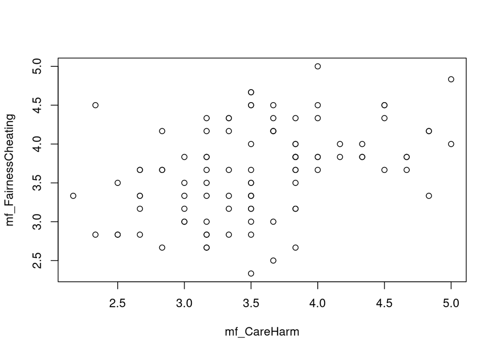

```r
podaci %>%
dplyr::select(., mf_CareHarm, mf_FairnessCheating) %>%
plot(.)
```

Histogram možemo dobiti pomoću funkcije `hist`.

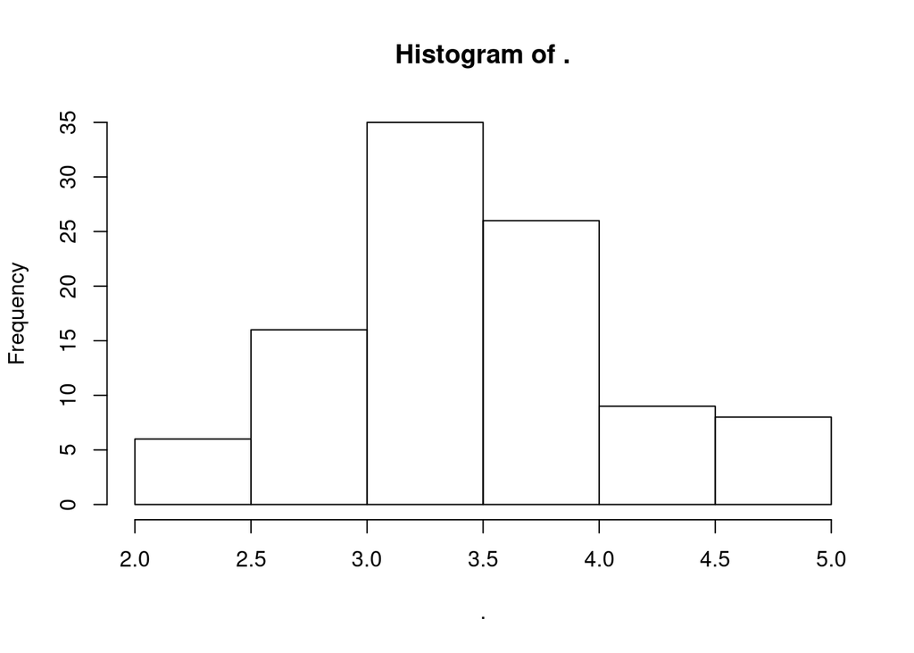

```r
podaci$mf_CareHarm %>% hist(.)
```

A možemo dobiti i graf gustoće distribucije tako da varijablu prvo bacimo u funkciju `density`, a potom u `plot`.

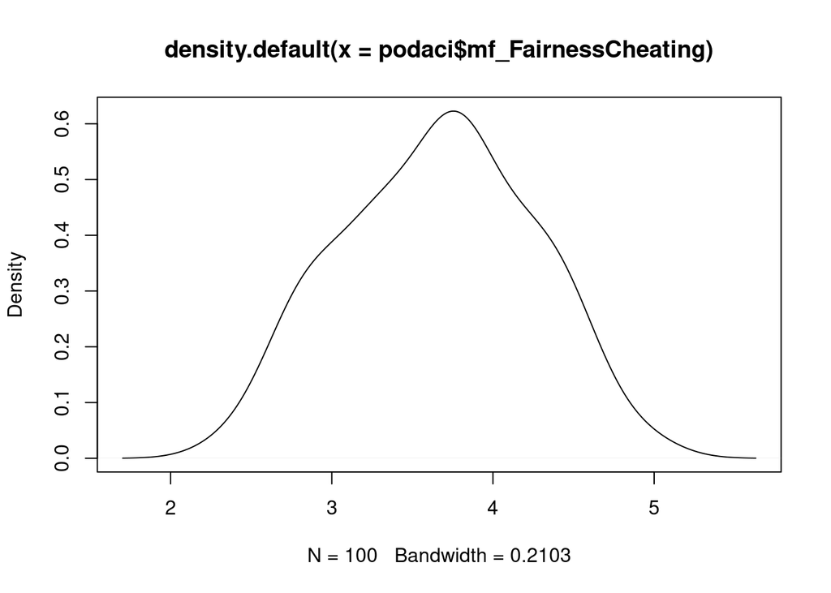

```r
plot(density(podaci$mf_FairnessCheating))
```

Moje poznavanje base grafike staje otprilike ovdje jer za vizualizacije koristim paket `ggplot`, koji je nekad nešto zahtjevniji, ali je i dosta moćniji. `ggplot` dolazi s funkcijom `qplot` (*quick plot*), koja služi za brzinsko crtanje. Dijagram raspršenja, recimo, možemo dobiti isto kao i s base `plotom`, ali ovaj je nešto ljepši.

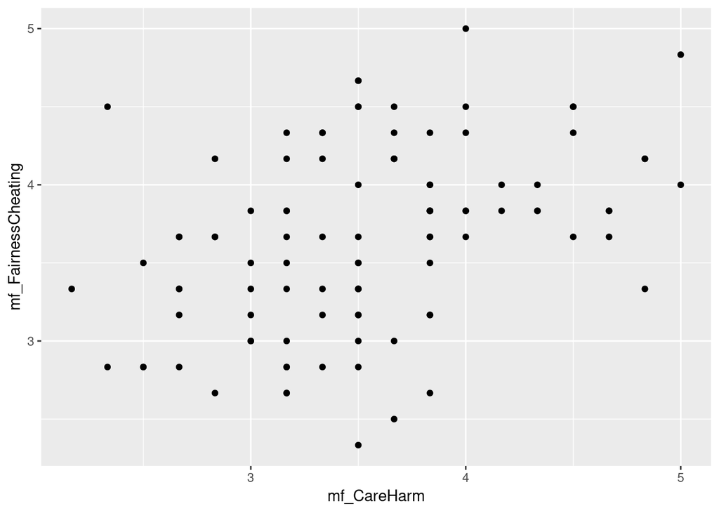

```r
ggplot2::qplot(data = podaci, x = mf_CareHarm, y = mf_FairnessCheating)
```

A lako možemo promijeniti boju točaka na temelju, recimo, spola.

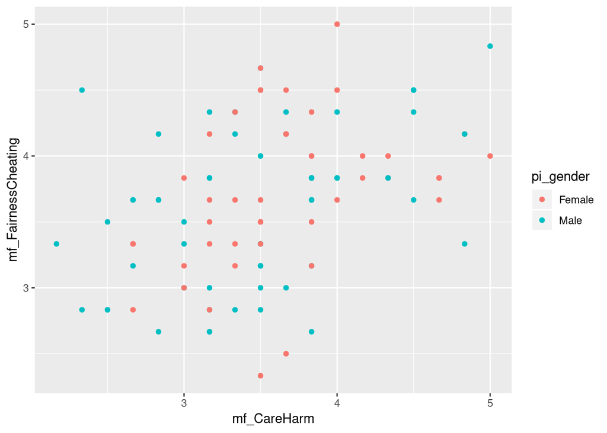

```r
ggplot2::qplot(data = podaci, x = mf_CareHarm, y = mf_FairnessCheating,
              color = pi_gender)
```

Fora kod `ggplota` je u tome da se graf izgrađuje sloj po sloj. `qplot` nešto skraćuje taj proces, ali i dalje ostavlja mogućnost dodavanja slojeva pomoću operatora `+`. Kad bismo, recimo, grafu još htjeli dodati regresijske pravce za svaku skupinu, na kraj bismo dodali:

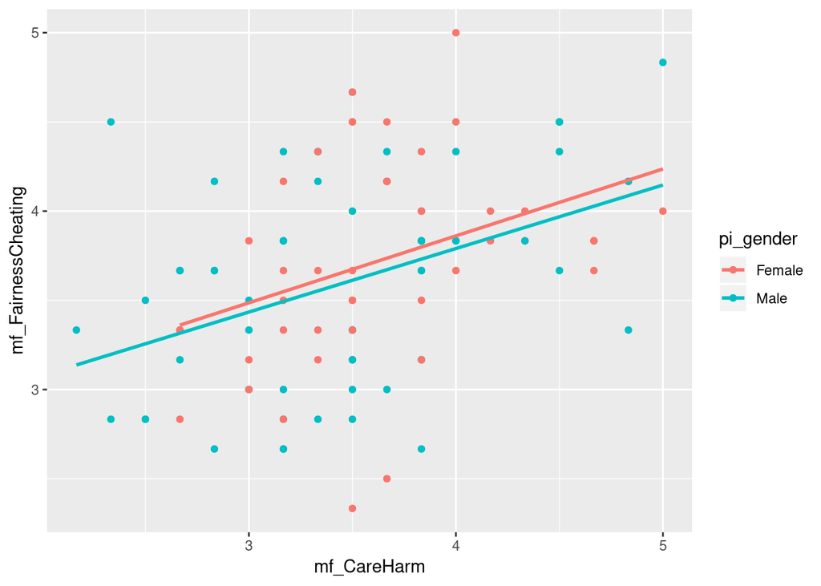

```r
ggplot2::qplot(data = podaci, x = mf_CareHarm, y = mf_FairnessCheating,
              color = pi_gender) + geom_smooth(method = 'lm', se = F)
```

Evo i histograma (koji je meni, ovako po difoltu, ružniji od base R-ovog):

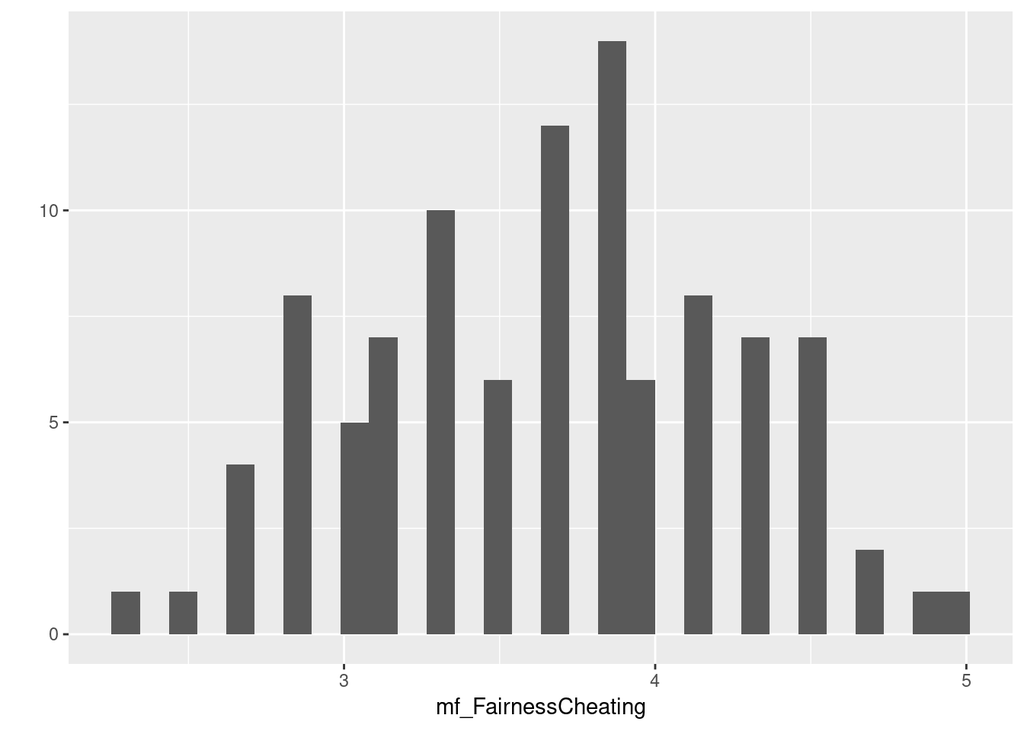

```r
ggplot2::qplot(data = podaci, x = mf_FairnessCheating,
              geom = 'histogram')
## `stat_bin()` using `bins = 30`. Pick better value with `binwidth`.
```

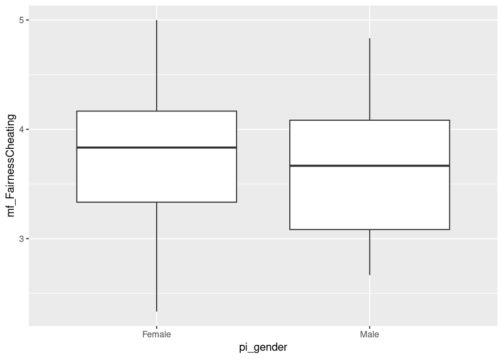

```r
ggplot2::qplot(data = podaci, x = pi_gender,
              y = mf_FairnessCheating, geom = 'boxplot')
```

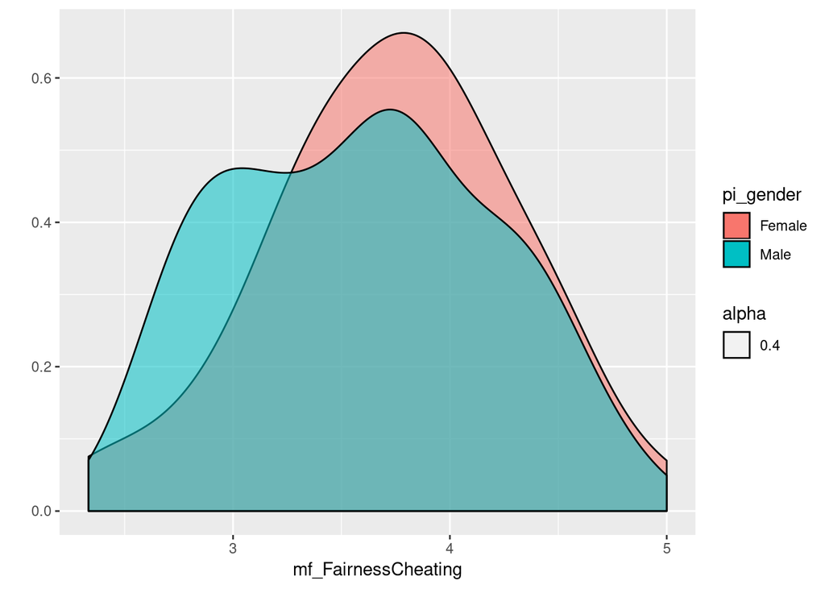

```r
ggplot2::qplot(data = podaci, x = mf_FairnessCheating,
              geom = 'density', fill = pi_gender,
              # određuje razinu transparentnosti
              alpha = .4)
```

S `qplotom` (a pogotovo s `ggplotom`) se može puno igrati, tako da neću pretjerano nastavljati ovaj niz. Igranje prepuštam čitatelju. Za kraj ovog dijela, pogledat ćemo jednu funkciju iz `psych` paketa koja daje dosta opširan vizualni sažetak podatka.

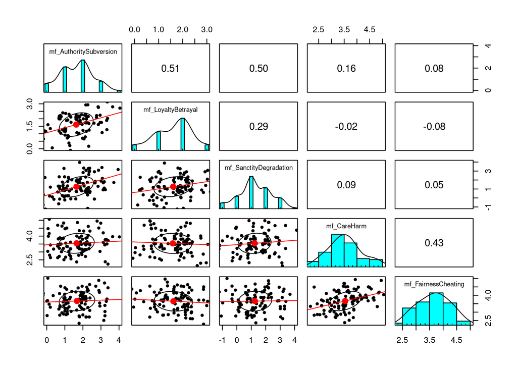

```r
podaci %>%
dplyr::select(., starts_with('mf_')) %>%
psych::pairs.panels(., lm = T, method = 'spearman',
                   # ovo je veličina slova, ne znam
                   # zašto se zove cex...
                   cex = .5,
                   # malo razbaca točke koje se nalaze
                   # na istoj poziciji radi dobivanja
                   # boljeg dojma o broju jedinki
                   jiggle = T)
```